# Project: Ford GoBike System Data Exploration

Yu Tao 2020 12/28

- Introduction
- Questions to Answer
- Preliminary Wrangling (Gather/Assess/Clean)
- Univariate Exploration
- Bivariate Exploration
- Multivariate Exploration
- Summary and Conclusion

## Introduction

In this project, I explored the **Ford GoBike system data**. This data set includes information about individual rides made in a bike-sharing system covering the greater San Francisco Bay area. The data set was directly downloaded from the Udacity Data Analyst Nanodegree project website, the file is named **201902-Fordgobike-Tripdata.csv**.

## Questions to Answer

To help better explore the data, I listed several questions I'd like to answer:

- When are most trips taken in terms of time of day or day of the week?
- How long does the average trip take?
- Does the above depend on if a user is a subscriber or customer?

It is almost certain that after the exploration, we will come up with more questions and interesting findings, therefore, a summary will be given at the end of this project.

## Preliminary Wrangling

First, let's import the necessary libraries for exploration.

```python
# import all packages and set plots to be embedded inline
import numpy as np
import pandas as pd
import matplotlib.pyplot as plt
import seaborn as sns

%matplotlib inline

import geopy.distance # find distance from longitudes and latitudes

from sklearn.linear_model import LinearRegression # regression model

import warnings
warnings.filterwarnings('ignore')
```

### Gather data

Next, I will load the GoBike data set to a pandas dataframe called **df_bike**.

```python
# load the csv data
df_bike = pd.read_csv('201902-fordgobike-tripdata.csv')
```

### Assess data

```python
# check the head
df_bike.head()
```

|  | duration_sec | start_time | end_time | start_station_id | start_station_name | start_station_latitude | start_station_longitude | end_station_id | end_station_name | end_station_latitude | end_station_longitude | bike_id | user_type | member_birth_year | member_gender | bike_share_for_all_trip |
| --- | --- | --- | --- | --- | --- | --- | --- | --- | --- | --- | --- | --- | --- | --- | --- | --- |
| 0 | 52185 | 2019-02-28 17:32:10.1450 | 2019-03-01 08:01:55.9750 | 21.0 | Montgomery St BART Station (Market St at 2nd St) | 37.789625 | -122.400811 | 13.0 | Commercial St at Montgomery St | 37.794231 | -122.402923 | 4902 | Customer | 1984.0 | Male | No |
| 1 | 42521 | 2019-02-28 18:53:21.7890 | 2019-03-01 06:42:03.0560 | 23.0 | The Embarcadero at Steuart St | 37.791464 | -122.391034 | 81.0 | Berry St at 4th St | 37.775880 | -122.393170 | 2535 | Customer | NaN | NaN | No |
| 2 | 61854 | 2019-02-28 12:13:13.2180 | 2019-03-01 05:24:08.1460 | 86.0 | Market St at Dolores St | 37.769305 | -122.426826 | 3.0 | Powell St BART Station (Market St at 4th St) | 37.786375 | -122.404904 | 5905 | Customer | 1972.0 | Male | No |
| 3 | 36490 | 2019-02-28 17:54:26.0100 | 2019-03-01 04:02:36.8420 | 375.0 | Grove St at Masonic Ave | 37.774836 | -122.446546 | 70.0 | Central Ave at Fell St | 37.773311 | -122.444293 | 6638 | Subscriber | 1989.0 | Other | No |
| 4 | 1585 | 2019-02-28 23:54:18.5490 | 2019-03-01 00:20:44.0740 | 7.0 | Frank H Ogawa Plaza | 37.804562 | -122.271738 | 222.0 | 10th Ave at E 15th St | 37.792714 | -122.248780 | 4898 | Subscriber | 1974.0 | Male | Yes |

```python
# find the time range of our bike data set
print (df_bike['start_time'].min(), df_bike['start_time'].max())
print (df_bike['end_time'].min(), df_bike['end_time'].max())
```

```
2019-02-01 00:00:20.6360 2019-02-28 23:59:18.5480
2019-02-01 00:04:52.0580 2019-03-01 08:01:55.9750
```

As we can see, each observation contains the duration, start/end time, start/end station name/position of the ride, and basic infomation about the rider (gender, birthyear, customer/subscriber). The data set records all the renting activities in **February 2019**.

```python
# check the info
df_bike.info()
```

```
<class 'pandas.core.frame.DataFrame'>
RangeIndex: 183412 entries, 0 to 183411
Data columns (total 16 columns):
duration_sec               183412 non-null int64
start_time                 183412 non-null object
end_time                   183412 non-null object
start_station_id           183215 non-null float64
start_station_name         183215 non-null object
start_station_latitude     183412 non-null float64
start_station_longitude    183412 non-null float64
end_station_id             183215 non-null float64
end_station_name           183215 non-null object
end_station_latitude       183412 non-null float64
end_station_longitude      183412 non-null float64
bike_id                    183412 non-null int64
user_type                  183412 non-null object
member_birth_year          175147 non-null float64
member_gender              175147 non-null object
bike_share_for_all_trip    183412 non-null object
dtypes: float64(7), int64(2), object(7)
memory usage: 22.4+ MB
```

In this data set, there are **183412 observations and 16 features**. There are some missing values in the columns of **start/end station id and name, member birthyear and gender**. However, in the birthyear and gender columns, we don't necessary need to have values since the riders have the rights not to share their personal information, therefore, missing values in these columns should be fine.

```python
# check for duplicate observations
df_bike.duplicated().sum()
```

```
0
```

It's good we don't have duplicate entries in our data set. Now let's focus on the missing start/end station id and name, first I queried on all null start station id.

```python
# check null start_station_id
df_bike[df_bike['start_station_id'].isnull()]
```

|  | duration_sec | start_time | end_time | start_station_id | start_station_name | start_station_latitude | start_station_longitude | end_station_id | end_station_name | end_station_latitude | end_station_longitude | bike_id | user_type | member_birth_year | member_gender | bike_share_for_all_trip |
| --- | --- | --- | --- | --- | --- | --- | --- | --- | --- | --- | --- | --- | --- | --- | --- | --- |
| 475 | 1709 | 2019-02-28 20:55:53.9320 | 2019-02-28 21:24:23.7380 | NaN | NaN | 37.40 | -121.94 | NaN | NaN | 37.40 | -121.93 | 4211 | Customer | 1991.0 | Female | No |
| 1733 | 1272 | 2019-02-28 18:32:34.2730 | 2019-02-28 18:53:46.7270 | NaN | NaN | 37.40 | -121.94 | NaN | NaN | 37.41 | -121.96 | 4174 | Subscriber | 1980.0 | Male | No |
| 3625 | 142 | 2019-02-28 17:10:46.5290 | 2019-02-28 17:13:09.4310 | NaN | NaN | 37.41 | -121.95 | NaN | NaN | 37.41 | -121.96 | 4283 | Subscriber | 1988.0 | Male | No |
| 4070 | 585 | 2019-02-28 16:28:45.9340 | 2019-02-28 16:38:31.3320 | NaN | NaN | 37.39 | -121.93 | NaN | NaN | 37.40 | -121.92 | 4089 | Subscriber | 1984.0 | Male | Yes |
| 5654 | 509 | 2019-02-28 12:30:17.1310 | 2019-02-28 12:38:46.3290 | NaN | NaN | 37.40 | -121.92 | NaN | NaN | 37.39 | -121.93 | 4089 | Subscriber | 1984.0 | Male | Yes |
| 6214 | 1334 | 2019-02-28 10:32:47.9300 | 2019-02-28 10:55:02.0280 | NaN | NaN | 37.40 | -121.93 | NaN | NaN | 37.38 | -121.93 | 4150 | Customer | 1990.0 | Male | No |
| 8499 | 240 | 2019-02-28 08:23:07.0920 | 2019-02-28 08:27:07.2890 | NaN | NaN | 37.41 | -121.96 | NaN | NaN | 37.41 | -121.95 | 4283 | Subscriber | 1988.0 | Male | No |
| 8783 | 883 | 2019-02-28 07:58:07.3720 | 2019-02-28 08:12:51.2760 | NaN | NaN | 37.41 | -121.96 | NaN | NaN | 37.40 | -121.94 | 4211 | Subscriber | 1980.0 | Male | No |
| 10967 | 116 | 2019-02-27 19:25:57.0360 | 2019-02-27 19:27:54.0260 | NaN | NaN | 37.41 | -121.95 | NaN | NaN | 37.41 | -121.95 | 4283 | Subscriber | 1988.0 | Male | No |
| 11071 | 828 | 2019-02-27 19:03:14.6380 | 2019-02-27 19:17:03.4340 | NaN | NaN | 37.40 | -121.94 | NaN | NaN | 37.41 | -121.96 | 4091 | Subscriber | 1980.0 | Male | No |
| 13945 | 399 | 2019-02-27 14:06:51.7720 | 2019-02-27 14:13:31.6720 | NaN | NaN | 37.41 | -121.95 | NaN | NaN | 37.41 | -121.96 | 3975 | Subscriber | 1995.0 | Male | Yes |
| 14073 | 402 | 2019-02-27 13:37:01.8640 | 2019-02-27 13:43:44.3600 | NaN | NaN | 37.41 | -121.95 | NaN | NaN | 37.41 | -121.95 | 3975 | Subscriber | 1995.0 | Male | Yes |
| 14115 | 870 | 2019-02-27 13:17:28.6630 | 2019-02-27 13:31:59.1710 | NaN | NaN | 37.40 | -121.93 | NaN | NaN | 37.41 | -121.95 | 4168 | Customer | 1982.0 | Male | No |
| 14276 | 856 | 2019-02-27 12:42:38.9310 | 2019-02-27 12:56:55.0260 | NaN | NaN | 37.41 | -121.94 | NaN | NaN | 37.41 | -121.96 | 4211 | Subscriber | 1999.0 | Female | No |
| 15298 | 890 | 2019-02-27 09:33:32.5720 | 2019-02-27 09:48:23.0750 | NaN | NaN | 37.41 | -121.96 | NaN | NaN | 37.41 | -121.94 | 4211 | Subscriber | 1999.0 | Female | No |
| 15932 | 186 | 2019-02-27 09:01:57.4740 | 2019-02-27 09:05:03.9760 | NaN | NaN | 37.41 | -121.96 | NaN | NaN | 37.41 | -121.95 | 4283 | Subscriber | 1988.0 | Male | No |
| 16746 | 1005 | 2019-02-27 08:00:53.5280 | 2019-02-27 08:17:38.5340 | NaN | NaN | 37.41 | -121.96 | NaN | NaN | 37.40 | -121.94 | 4091 | Subscriber | 1980.0 | Male | No |
| 17749 | 316 | 2019-02-26 20:50:30.7760 | 2019-02-26 20:55:47.0760 | NaN | NaN | 37.41 | -121.96 | NaN | NaN | 37.41 | -121.95 | 4239 | Customer | 1992.0 | Male | No |
| 17908 | 393 | 2019-02-26 20:11:35.0800 | 2019-02-26 20:18:08.6700 | NaN | NaN | 37.40 | -121.94 | NaN | NaN | 37.40 | -121.93 | 4250 | Subscriber | 1990.0 | Male | No |
| 18573 | 142 | 2019-02-26 18:22:48.7720 | 2019-02-26 18:25:10.7740 | NaN | NaN | 37.41 | -121.95 | NaN | NaN | 37.41 | -121.95 | 4283 | Subscriber | 1988.0 | Male | No |
| 18639 | 954 | 2019-02-26 18:02:37.2290 | 2019-02-26 18:18:32.0650 | NaN | NaN | 37.40 | -121.94 | NaN | NaN | 37.41 | -121.96 | 4239 | Subscriber | 1980.0 | Male | No |
| 19033 | 913 | 2019-02-26 17:29:26.5680 | 2019-02-26 17:44:39.7700 | NaN | NaN | 37.40 | -121.93 | NaN | NaN | 37.40 | -121.93 | 4168 | Customer | 1987.0 | Female | No |
| 19932 | 327 | 2019-02-26 15:00:30.5340 | 2019-02-26 15:05:58.0320 | NaN | NaN | 37.41 | -121.95 | NaN | NaN | 37.41 | -121.95 | 4124 | Subscriber | 1999.0 | Male | No |
| 21233 | 170 | 2019-02-26 09:30:48.1350 | 2019-02-26 09:33:38.6190 | NaN | NaN | 37.41 | -121.96 | NaN | NaN | 37.41 | -121.95 | 4283 | Subscriber | 1988.0 | Male | No |
| 22306 | 1123 | 2019-02-26 08:05:08.6320 | 2019-02-26 08:23:52.0330 | NaN | NaN | 37.41 | -121.96 | NaN | NaN | 37.40 | -121.94 | 4239 | Subscriber | 1980.0 | Male | No |
| 22893 | 301 | 2019-02-26 02:10:14.2240 | 2019-02-26 02:15:15.7340 | NaN | NaN | 37.41 | -121.95 | NaN | NaN | 37.41 | -121.96 | 4239 | Customer | 1992.0 | Male | No |
| 23515 | 352 | 2019-02-25 20:13:00.9730 | 2019-02-25 20:18:53.0700 | NaN | NaN | 37.41 | -121.96 | NaN | NaN | 37.41 | -121.96 | 4239 | Customer | 1992.0 | Male | No |
| 24102 | 150 | 2019-02-25 18:53:35.2670 | 2019-02-25 18:56:05.3730 | NaN | NaN | 37.41 | -121.95 | NaN | NaN | 37.41 | -121.95 | 4283 | Subscriber | 1988.0 | Male | No |
| 24429 | 806 | 2019-02-25 18:11:33.0340 | 2019-02-25 18:24:59.5310 | NaN | NaN | 37.41 | -121.94 | NaN | NaN | 37.41 | -121.94 | 4189 | Subscriber | 1994.0 | Female | Yes |
| 24539 | 997 | 2019-02-25 17:57:40.5330 | 2019-02-25 18:14:18.3300 | NaN | NaN | 37.40 | -121.94 | NaN | NaN | 37.41 | -121.96 | 4239 | Subscriber | 1980.0 | Male | No |
| ... | ... | ... | ... | ... | ... | ... | ... | ... | ... | ... | ... | ... | ... | ... | ... | ... |
| 130572 | 1200 | 2019-02-09 16:36:30.3070 | 2019-02-09 16:56:31.2460 | NaN | NaN | 37.40 | -121.93 | NaN | NaN | 37.40 | -121.93 | 4245 | Customer | 1984.0 | Female | No |
| 130846 | 481 | 2019-02-09 15:09:44.3840 | 2019-02-09 15:17:45.7220 | NaN | NaN | 37.42 | -121.95 | NaN | NaN | 37.41 | -121.96 | 4141 | Subscriber | 1999.0 | Male | No |
| 130944 | 339 | 2019-02-09 14:40:39.5040 | 2019-02-09 14:46:18.8620 | NaN | NaN | 37.41 | -121.95 | NaN | NaN | 37.42 | -121.95 | 4141 | Subscriber | 1999.0 | Male | No |
| 131475 | 527 | 2019-02-09 12:24:39.8020 | 2019-02-09 12:33:26.9450 | NaN | NaN | 37.42 | -121.96 | NaN | NaN | 37.41 | -121.96 | 4239 | Subscriber | 1977.0 | Male | No |
| 131502 | 795 | 2019-02-09 12:10:29.1640 | 2019-02-09 12:23:44.7060 | NaN | NaN | 37.40 | -121.94 | NaN | NaN | 37.40 | -121.94 | 4174 | Customer | 1988.0 | Female | No |
| 131575 | 2233 | 2019-02-09 11:26:46.8750 | 2019-02-09 12:04:00.0710 | NaN | NaN | 37.41 | -121.95 | NaN | NaN | 37.42 | -121.96 | 4130 | Customer | 1991.0 | Male | No |
| 131645 | 303 | 2019-02-09 11:28:57.1210 | 2019-02-09 11:34:01.0220 | NaN | NaN | 37.42 | -121.95 | NaN | NaN | 37.42 | -121.96 | 4239 | Subscriber | 1977.0 | Male | No |
| 131750 | 276 | 2019-02-09 11:02:12.2670 | 2019-02-09 11:06:49.1040 | NaN | NaN | 37.41 | -121.95 | NaN | NaN | 37.42 | -121.95 | 4239 | Subscriber | 1977.0 | Male | No |
| 132593 | 439 | 2019-02-08 23:52:25.8470 | 2019-02-08 23:59:44.9270 | NaN | NaN | 37.42 | -121.95 | NaN | NaN | 37.41 | -121.94 | 4162 | Customer | 1981.0 | Male | No |
| 135455 | 6725 | 2019-02-08 11:06:42.2950 | 2019-02-08 12:58:48.2570 | NaN | NaN | 37.41 | -121.96 | NaN | NaN | 37.41 | -121.96 | 4092 | Subscriber | 1999.0 | Male | No |
| 136317 | 1927 | 2019-02-08 09:41:14.3240 | 2019-02-08 10:13:22.0890 | NaN | NaN | 37.41 | -121.94 | NaN | NaN | 37.41 | -121.98 | 4125 | Customer | 1989.0 | Male | No |
| 137030 | 838 | 2019-02-08 08:57:23.1240 | 2019-02-08 09:11:21.5430 | NaN | NaN | 37.41 | -121.94 | NaN | NaN | 37.40 | -121.92 | 4249 | Subscriber | 1976.0 | Male | No |
| 142719 | 2031 | 2019-02-07 16:23:38.5680 | 2019-02-07 16:57:29.7450 | NaN | NaN | 37.41 | -121.98 | NaN | NaN | 37.41 | -121.94 | 4125 | Customer | 1989.0 | Male | No |
| 142864 | 3064 | 2019-02-07 15:53:33.2350 | 2019-02-07 16:44:37.8200 | NaN | NaN | 37.41 | -121.95 | NaN | NaN | 37.43 | -121.92 | 4275 | Customer | 1986.0 | Male | No |
| 144928 | 349 | 2019-02-07 10:39:21.0240 | 2019-02-07 10:45:10.3850 | NaN | NaN | 37.42 | -121.94 | NaN | NaN | 37.41 | -121.95 | 4157 | Subscriber | 2000.0 | Female | Yes |
| 145154 | 1503 | 2019-02-07 09:49:31.9250 | 2019-02-07 10:14:35.8680 | NaN | NaN | 37.41 | -121.95 | NaN | NaN | 37.41 | -121.98 | 4125 | Customer | 1989.0 | Male | No |
| 152178 | 366 | 2019-02-06 16:20:37.1020 | 2019-02-06 16:26:43.1650 | NaN | NaN | 37.41 | -121.95 | NaN | NaN | 37.42 | -121.94 | 4157 | Subscriber | 2000.0 | Female | Yes |
| 152648 | 660 | 2019-02-06 15:07:33.9600 | 2019-02-06 15:18:34.5620 | NaN | NaN | 37.40 | -121.92 | NaN | NaN | 37.41 | -121.94 | 4249 | Subscriber | 1976.0 | Male | No |
| 153088 | 789 | 2019-02-06 13:32:34.6330 | 2019-02-06 13:45:44.3340 | NaN | NaN | 37.41 | -121.94 | NaN | NaN | 37.41 | -121.96 | 4092 | Subscriber | 1999.0 | Female | No |
| 154695 | 968 | 2019-02-06 09:19:56.8780 | 2019-02-06 09:36:05.2380 | NaN | NaN | 37.41 | -121.96 | NaN | NaN | 37.41 | -121.94 | 4092 | Subscriber | 1999.0 | Female | No |
| 155470 | 984 | 2019-02-06 08:39:02.6480 | 2019-02-06 08:55:26.6830 | NaN | NaN | 37.41 | -121.94 | NaN | NaN | 37.40 | -121.92 | 4249 | Subscriber | 1976.0 | Male | No |
| 161400 | 1159 | 2019-02-05 14:53:30.4310 | 2019-02-05 15:12:49.4460 | NaN | NaN | 37.40 | -121.94 | NaN | NaN | 37.40 | -121.94 | 4174 | Customer | 1986.0 | Male | No |
| 161844 | 823 | 2019-02-05 13:28:05.5940 | 2019-02-05 13:41:49.3090 | NaN | NaN | 37.41 | -121.94 | NaN | NaN | 37.41 | -121.96 | 4092 | Subscriber | 1999.0 | Male | No |
| 172481 | 3791 | 2019-02-03 14:53:55.9470 | 2019-02-03 15:57:07.0860 | NaN | NaN | 37.40 | -121.94 | NaN | NaN | 37.40 | -121.94 | 4174 | Subscriber | 1977.0 | Male | No |
| 174807 | 8209 | 2019-02-02 14:26:59.9650 | 2019-02-02 16:43:49.5180 | NaN | NaN | 37.40 | -121.93 | NaN | NaN | 37.41 | -121.94 | 4249 | Subscriber | 1993.0 | Male | Yes |
| 176154 | 1447 | 2019-02-02 12:03:04.5440 | 2019-02-02 12:27:12.2670 | NaN | NaN | 37.40 | -121.93 | NaN | NaN | 37.40 | -121.93 | 4249 | Customer | 1984.0 | Male | No |
| 179730 | 309 | 2019-02-01 12:59:45.9690 | 2019-02-01 13:04:55.4260 | NaN | NaN | 37.40 | -121.94 | NaN | NaN | 37.40 | -121.93 | 4249 | Customer | 1987.0 | Female | No |
| 179970 | 659 | 2019-02-01 12:17:37.6750 | 2019-02-01 12:28:37.0140 | NaN | NaN | 37.41 | -121.96 | NaN | NaN | 37.41 | -121.94 | 4092 | Subscriber | 1999.0 | Female | No |
| 180106 | 2013 | 2019-02-01 11:33:55.1470 | 2019-02-01 12:07:28.9400 | NaN | NaN | 37.40 | -121.94 | NaN | NaN | 37.40 | -121.94 | 4251 | Customer | 1990.0 | Female | No |
| 181201 | 312 | 2019-02-01 09:26:34.8030 | 2019-02-01 09:31:46.9210 | NaN | NaN | 37.40 | -121.93 | NaN | NaN | 37.40 | -121.93 | 4208 | Subscriber | 1987.0 | Male | No |

197 rows × 16 columns

```python
# count on the latitude of the null start station id
df_bike[df_bike['start_station_id'].isnull()]['start_station_latitude'].value_counts()
```

```
37.41    101
37.40     63
37.42     21
37.39     11
37.38      1
Name: start_station_latitude, dtype: int64
```

```python
# count on the longitude of the null start station id
df_bike[df_bike['start_station_id'].isnull()]['start_station_longitude'].value_counts()
```

```
-121.94    57
-121.96    46
-121.93    46
-121.95    37
-121.92    10
-121.98     1
Name: start_station_longitude, dtype: int64
```

The missing start station ids seem to have similar latitudes (**37.38 to 37.42**) and longitudes (**-121.98 to -121.92**). Compared with those with start station id, these values are less accurate as well as they have less digits after the decimal point.

```python
# check the null end_station_id
df_bike[df_bike['end_station_id'].isnull()]
```

|  | duration_sec | start_time | end_time | start_station_id | start_station_name | start_station_latitude | start_station_longitude | end_station_id | end_station_name | end_station_latitude | end_station_longitude | bike_id | user_type | member_birth_year | member_gender | bike_share_for_all_trip |
| --- | --- | --- | --- | --- | --- | --- | --- | --- | --- | --- | --- | --- | --- | --- | --- | --- |
| 475 | 1709 | 2019-02-28 20:55:53.9320 | 2019-02-28 21:24:23.7380 | NaN | NaN | 37.40 | -121.94 | NaN | NaN | 37.40 | -121.93 | 4211 | Customer | 1991.0 | Female | No |
| 1733 | 1272 | 2019-02-28 18:32:34.2730 | 2019-02-28 18:53:46.7270 | NaN | NaN | 37.40 | -121.94 | NaN | NaN | 37.41 | -121.96 | 4174 | Subscriber | 1980.0 | Male | No |
| 3625 | 142 | 2019-02-28 17:10:46.5290 | 2019-02-28 17:13:09.4310 | NaN | NaN | 37.41 | -121.95 | NaN | NaN | 37.41 | -121.96 | 4283 | Subscriber | 1988.0 | Male | No |
| 4070 | 585 | 2019-02-28 16:28:45.9340 | 2019-02-28 16:38:31.3320 | NaN | NaN | 37.39 | -121.93 | NaN | NaN | 37.40 | -121.92 | 4089 | Subscriber | 1984.0 | Male | Yes |
| 5654 | 509 | 2019-02-28 12:30:17.1310 | 2019-02-28 12:38:46.3290 | NaN | NaN | 37.40 | -121.92 | NaN | NaN | 37.39 | -121.93 | 4089 | Subscriber | 1984.0 | Male | Yes |
| 6214 | 1334 | 2019-02-28 10:32:47.9300 | 2019-02-28 10:55:02.0280 | NaN | NaN | 37.40 | -121.93 | NaN | NaN | 37.38 | -121.93 | 4150 | Customer | 1990.0 | Male | No |
| 8499 | 240 | 2019-02-28 08:23:07.0920 | 2019-02-28 08:27:07.2890 | NaN | NaN | 37.41 | -121.96 | NaN | NaN | 37.41 | -121.95 | 4283 | Subscriber | 1988.0 | Male | No |
| 8783 | 883 | 2019-02-28 07:58:07.3720 | 2019-02-28 08:12:51.2760 | NaN | NaN | 37.41 | -121.96 | NaN | NaN | 37.40 | -121.94 | 4211 | Subscriber | 1980.0 | Male | No |
| 10967 | 116 | 2019-02-27 19:25:57.0360 | 2019-02-27 19:27:54.0260 | NaN | NaN | 37.41 | -121.95 | NaN | NaN | 37.41 | -121.95 | 4283 | Subscriber | 1988.0 | Male | No |
| 11071 | 828 | 2019-02-27 19:03:14.6380 | 2019-02-27 19:17:03.4340 | NaN | NaN | 37.40 | -121.94 | NaN | NaN | 37.41 | -121.96 | 4091 | Subscriber | 1980.0 | Male | No |
| 13945 | 399 | 2019-02-27 14:06:51.7720 | 2019-02-27 14:13:31.6720 | NaN | NaN | 37.41 | -121.95 | NaN | NaN | 37.41 | -121.96 | 3975 | Subscriber | 1995.0 | Male | Yes |
| 14073 | 402 | 2019-02-27 13:37:01.8640 | 2019-02-27 13:43:44.3600 | NaN | NaN | 37.41 | -121.95 | NaN | NaN | 37.41 | -121.95 | 3975 | Subscriber | 1995.0 | Male | Yes |
| 14115 | 870 | 2019-02-27 13:17:28.6630 | 2019-02-27 13:31:59.1710 | NaN | NaN | 37.40 | -121.93 | NaN | NaN | 37.41 | -121.95 | 4168 | Customer | 1982.0 | Male | No |
| 14276 | 856 | 2019-02-27 12:42:38.9310 | 2019-02-27 12:56:55.0260 | NaN | NaN | 37.41 | -121.94 | NaN | NaN | 37.41 | -121.96 | 4211 | Subscriber | 1999.0 | Female | No |
| 15298 | 890 | 2019-02-27 09:33:32.5720 | 2019-02-27 09:48:23.0750 | NaN | NaN | 37.41 | -121.96 | NaN | NaN | 37.41 | -121.94 | 4211 | Subscriber | 1999.0 | Female | No |
| 15932 | 186 | 2019-02-27 09:01:57.4740 | 2019-02-27 09:05:03.9760 | NaN | NaN | 37.41 | -121.96 | NaN | NaN | 37.41 | -121.95 | 4283 | Subscriber | 1988.0 | Male | No |
| 16746 | 1005 | 2019-02-27 08:00:53.5280 | 2019-02-27 08:17:38.5340 | NaN | NaN | 37.41 | -121.96 | NaN | NaN | 37.40 | -121.94 | 4091 | Subscriber | 1980.0 | Male | No |
| 17749 | 316 | 2019-02-26 20:50:30.7760 | 2019-02-26 20:55:47.0760 | NaN | NaN | 37.41 | -121.96 | NaN | NaN | 37.41 | -121.95 | 4239 | Customer | 1992.0 | Male | No |
| 17908 | 393 | 2019-02-26 20:11:35.0800 | 2019-02-26 20:18:08.6700 | NaN | NaN | 37.40 | -121.94 | NaN | NaN | 37.40 | -121.93 | 4250 | Subscriber | 1990.0 | Male | No |
| 18573 | 142 | 2019-02-26 18:22:48.7720 | 2019-02-26 18:25:10.7740 | NaN | NaN | 37.41 | -121.95 | NaN | NaN | 37.41 | -121.95 | 4283 | Subscriber | 1988.0 | Male | No |
| 18639 | 954 | 2019-02-26 18:02:37.2290 | 2019-02-26 18:18:32.0650 | NaN | NaN | 37.40 | -121.94 | NaN | NaN | 37.41 | -121.96 | 4239 | Subscriber | 1980.0 | Male | No |
| 19033 | 913 | 2019-02-26 17:29:26.5680 | 2019-02-26 17:44:39.7700 | NaN | NaN | 37.40 | -121.93 | NaN | NaN | 37.40 | -121.93 | 4168 | Customer | 1987.0 | Female | No |
| 19932 | 327 | 2019-02-26 15:00:30.5340 | 2019-02-26 15:05:58.0320 | NaN | NaN | 37.41 | -121.95 | NaN | NaN | 37.41 | -121.95 | 4124 | Subscriber | 1999.0 | Male | No |
| 21233 | 170 | 2019-02-26 09:30:48.1350 | 2019-02-26 09:33:38.6190 | NaN | NaN | 37.41 | -121.96 | NaN | NaN | 37.41 | -121.95 | 4283 | Subscriber | 1988.0 | Male | No |
| 22306 | 1123 | 2019-02-26 08:05:08.6320 | 2019-02-26 08:23:52.0330 | NaN | NaN | 37.41 | -121.96 | NaN | NaN | 37.40 | -121.94 | 4239 | Subscriber | 1980.0 | Male | No |
| 22893 | 301 | 2019-02-26 02:10:14.2240 | 2019-02-26 02:15:15.7340 | NaN | NaN | 37.41 | -121.95 | NaN | NaN | 37.41 | -121.96 | 4239 | Customer | 1992.0 | Male | No |
| 23515 | 352 | 2019-02-25 20:13:00.9730 | 2019-02-25 20:18:53.0700 | NaN | NaN | 37.41 | -121.96 | NaN | NaN | 37.41 | -121.96 | 4239 | Customer | 1992.0 | Male | No |
| 24102 | 150 | 2019-02-25 18:53:35.2670 | 2019-02-25 18:56:05.3730 | NaN | NaN | 37.41 | -121.95 | NaN | NaN | 37.41 | -121.95 | 4283 | Subscriber | 1988.0 | Male | No |
| 24429 | 806 | 2019-02-25 18:11:33.0340 | 2019-02-25 18:24:59.5310 | NaN | NaN | 37.41 | -121.94 | NaN | NaN | 37.41 | -121.94 | 4189 | Subscriber | 1994.0 | Female | Yes |
| 24539 | 997 | 2019-02-25 17:57:40.5330 | 2019-02-25 18:14:18.3300 | NaN | NaN | 37.40 | -121.94 | NaN | NaN | 37.41 | -121.96 | 4239 | Subscriber | 1980.0 | Male | No |
| ... | ... | ... | ... | ... | ... | ... | ... | ... | ... | ... | ... | ... | ... | ... | ... | ... |
| 130572 | 1200 | 2019-02-09 16:36:30.3070 | 2019-02-09 16:56:31.2460 | NaN | NaN | 37.40 | -121.93 | NaN | NaN | 37.40 | -121.93 | 4245 | Customer | 1984.0 | Female | No |
| 130846 | 481 | 2019-02-09 15:09:44.3840 | 2019-02-09 15:17:45.7220 | NaN | NaN | 37.42 | -121.95 | NaN | NaN | 37.41 | -121.96 | 4141 | Subscriber | 1999.0 | Male | No |
| 130944 | 339 | 2019-02-09 14:40:39.5040 | 2019-02-09 14:46:18.8620 | NaN | NaN | 37.41 | -121.95 | NaN | NaN | 37.42 | -121.95 | 4141 | Subscriber | 1999.0 | Male | No |
| 131475 | 527 | 2019-02-09 12:24:39.8020 | 2019-02-09 12:33:26.9450 | NaN | NaN | 37.42 | -121.96 | NaN | NaN | 37.41 | -121.96 | 4239 | Subscriber | 1977.0 | Male | No |
| 131502 | 795 | 2019-02-09 12:10:29.1640 | 2019-02-09 12:23:44.7060 | NaN | NaN | 37.40 | -121.94 | NaN | NaN | 37.40 | -121.94 | 4174 | Customer | 1988.0 | Female | No |
| 131575 | 2233 | 2019-02-09 11:26:46.8750 | 2019-02-09 12:04:00.0710 | NaN | NaN | 37.41 | -121.95 | NaN | NaN | 37.42 | -121.96 | 4130 | Customer | 1991.0 | Male | No |
| 131645 | 303 | 2019-02-09 11:28:57.1210 | 2019-02-09 11:34:01.0220 | NaN | NaN | 37.42 | -121.95 | NaN | NaN | 37.42 | -121.96 | 4239 | Subscriber | 1977.0 | Male | No |
| 131750 | 276 | 2019-02-09 11:02:12.2670 | 2019-02-09 11:06:49.1040 | NaN | NaN | 37.41 | -121.95 | NaN | NaN | 37.42 | -121.95 | 4239 | Subscriber | 1977.0 | Male | No |
| 132593 | 439 | 2019-02-08 23:52:25.8470 | 2019-02-08 23:59:44.9270 | NaN | NaN | 37.42 | -121.95 | NaN | NaN | 37.41 | -121.94 | 4162 | Customer | 1981.0 | Male | No |
| 135455 | 6725 | 2019-02-08 11:06:42.2950 | 2019-02-08 12:58:48.2570 | NaN | NaN | 37.41 | -121.96 | NaN | NaN | 37.41 | -121.96 | 4092 | Subscriber | 1999.0 | Male | No |
| 136317 | 1927 | 2019-02-08 09:41:14.3240 | 2019-02-08 10:13:22.0890 | NaN | NaN | 37.41 | -121.94 | NaN | NaN | 37.41 | -121.98 | 4125 | Customer | 1989.0 | Male | No |
| 137030 | 838 | 2019-02-08 08:57:23.1240 | 2019-02-08 09:11:21.5430 | NaN | NaN | 37.41 | -121.94 | NaN | NaN | 37.40 | -121.92 | 4249 | Subscriber | 1976.0 | Male | No |
| 142719 | 2031 | 2019-02-07 16:23:38.5680 | 2019-02-07 16:57:29.7450 | NaN | NaN | 37.41 | -121.98 | NaN | NaN | 37.41 | -121.94 | 4125 | Customer | 1989.0 | Male | No |
| 142864 | 3064 | 2019-02-07 15:53:33.2350 | 2019-02-07 16:44:37.8200 | NaN | NaN | 37.41 | -121.95 | NaN | NaN | 37.43 | -121.92 | 4275 | Customer | 1986.0 | Male | No |
| 144928 | 349 | 2019-02-07 10:39:21.0240 | 2019-02-07 10:45:10.3850 | NaN | NaN | 37.42 | -121.94 | NaN | NaN | 37.41 | -121.95 | 4157 | Subscriber | 2000.0 | Female | Yes |
| 145154 | 1503 | 2019-02-07 09:49:31.9250 | 2019-02-07 10:14:35.8680 | NaN | NaN | 37.41 | -121.95 | NaN | NaN | 37.41 | -121.98 | 4125 | Customer | 1989.0 | Male | No |
| 152178 | 366 | 2019-02-06 16:20:37.1020 | 2019-02-06 16:26:43.1650 | NaN | NaN | 37.41 | -121.95 | NaN | NaN | 37.42 | -121.94 | 4157 | Subscriber | 2000.0 | Female | Yes |
| 152648 | 660 | 2019-02-06 15:07:33.9600 | 2019-02-06 15:18:34.5620 | NaN | NaN | 37.40 | -121.92 | NaN | NaN | 37.41 | -121.94 | 4249 | Subscriber | 1976.0 | Male | No |
| 153088 | 789 | 2019-02-06 13:32:34.6330 | 2019-02-06 13:45:44.3340 | NaN | NaN | 37.41 | -121.94 | NaN | NaN | 37.41 | -121.96 | 4092 | Subscriber | 1999.0 | Female | No |
| 154695 | 968 | 2019-02-06 09:19:56.8780 | 2019-02-06 09:36:05.2380 | NaN | NaN | 37.41 | -121.96 | NaN | NaN | 37.41 | -121.94 | 4092 | Subscriber | 1999.0 | Female | No |
| 155470 | 984 | 2019-02-06 08:39:02.6480 | 2019-02-06 08:55:26.6830 | NaN | NaN | 37.41 | -121.94 | NaN | NaN | 37.40 | -121.92 | 4249 | Subscriber | 1976.0 | Male | No |
| 161400 | 1159 | 2019-02-05 14:53:30.4310 | 2019-02-05 15:12:49.4460 | NaN | NaN | 37.40 | -121.94 | NaN | NaN | 37.40 | -121.94 | 4174 | Customer | 1986.0 | Male | No |
| 161844 | 823 | 2019-02-05 13:28:05.5940 | 2019-02-05 13:41:49.3090 | NaN | NaN | 37.41 | -121.94 | NaN | NaN | 37.41 | -121.96 | 4092 | Subscriber | 1999.0 | Male | No |
| 172481 | 3791 | 2019-02-03 14:53:55.9470 | 2019-02-03 15:57:07.0860 | NaN | NaN | 37.40 | -121.94 | NaN | NaN | 37.40 | -121.94 | 4174 | Subscriber | 1977.0 | Male | No |
| 174807 | 8209 | 2019-02-02 14:26:59.9650 | 2019-02-02 16:43:49.5180 | NaN | NaN | 37.40 | -121.93 | NaN | NaN | 37.41 | -121.94 | 4249 | Subscriber | 1993.0 | Male | Yes |
| 176154 | 1447 | 2019-02-02 12:03:04.5440 | 2019-02-02 12:27:12.2670 | NaN | NaN | 37.40 | -121.93 | NaN | NaN | 37.40 | -121.93 | 4249 | Customer | 1984.0 | Male | No |
| 179730 | 309 | 2019-02-01 12:59:45.9690 | 2019-02-01 13:04:55.4260 | NaN | NaN | 37.40 | -121.94 | NaN | NaN | 37.40 | -121.93 | 4249 | Customer | 1987.0 | Female | No |
| 179970 | 659 | 2019-02-01 12:17:37.6750 | 2019-02-01 12:28:37.0140 | NaN | NaN | 37.41 | -121.96 | NaN | NaN | 37.41 | -121.94 | 4092 | Subscriber | 1999.0 | Female | No |
| 180106 | 2013 | 2019-02-01 11:33:55.1470 | 2019-02-01 12:07:28.9400 | NaN | NaN | 37.40 | -121.94 | NaN | NaN | 37.40 | -121.94 | 4251 | Customer | 1990.0 | Female | No |
| 181201 | 312 | 2019-02-01 09:26:34.8030 | 2019-02-01 09:31:46.9210 | NaN | NaN | 37.40 | -121.93 | NaN | NaN | 37.40 | -121.93 | 4208 | Subscriber | 1987.0 | Male | No |

197 rows × 16 columns

```python
# count on the latitude of the null end station id
df_bike[df_bike['end_station_id'].isnull()]['end_station_latitude'].value_counts()
```

```
37.41    98
37.40    65
37.42    18
37.39    13
37.38     2
37.43     1
Name: end_station_latitude, dtype: int64
```

```python
# count on the longitude of the null end station id
df_bike[df_bike['end_station_id'].isnull()]['end_station_longitude'].value_counts()
```

```
-121.94    55
-121.93    50
-121.96    46
-121.95    33
-121.92    11
-121.98     2
Name: end_station_longitude, dtype: int64
```

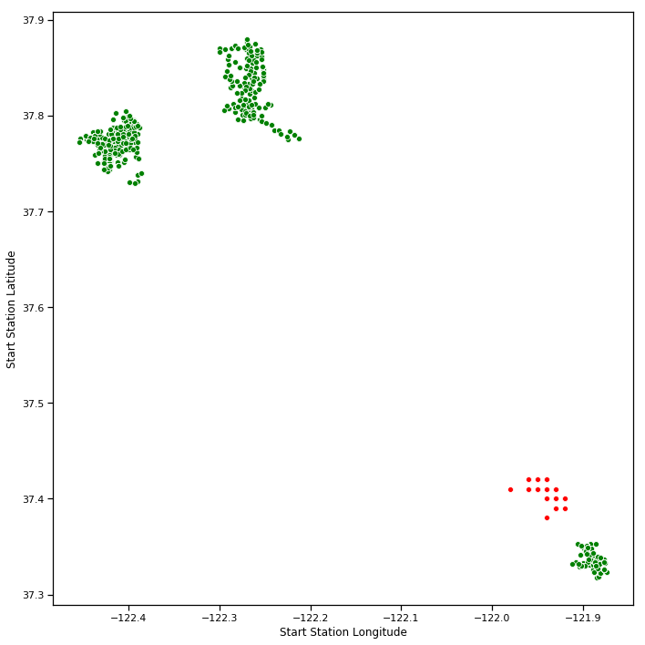

```python
# plot all latitudes and longitudes, those with missing ids in red
# first on start stations
with sns.plotting_context("notebook"):
    # create a matplotlib figure
    fig, ax = plt.subplots(figsize = (10,10))
    sns.scatterplot(y = "start_station_latitude", x = "start_station_longitude", data = df_bike[df_bike['start_station_id'].isnull()], color = 'r')
    sns.scatterplot(y = "start_station_latitude", x = "start_station_longitude", data = df_bike.dropna(subset=["start_station_id"]), color = 'g')
    plt.ylabel('Start Station Latitude')
    plt.xlabel('Start Station Longitude')
    plt.tight_layout()
```

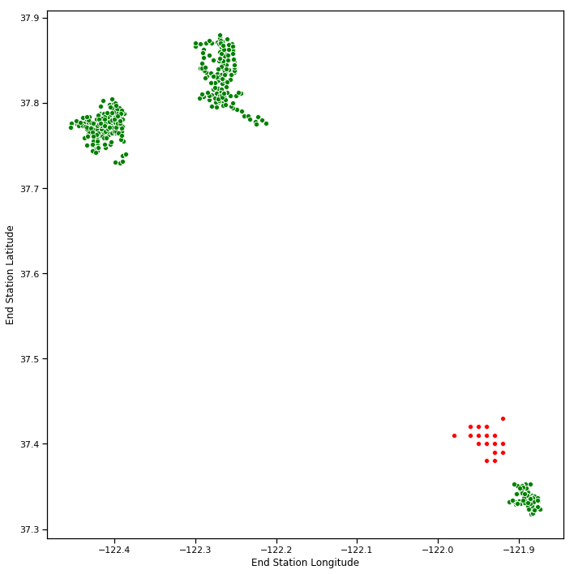

```python
# plot all latitudes and longitudes, those with missing ids in red
# second on end stations
with sns.plotting_context("notebook"):
    # create a matplotlib figure
    fig, ax = plt.subplots(figsize = (10,10))
    sns.scatterplot(y = "end_station_latitude", x = "end_station_longitude", data = df_bike[df_bike['end_station_id'].isnull()], color = 'r')
    sns.scatterplot(y = "end_station_latitude", x = "end_station_longitude", data = df_bike.dropna(subset=["end_station_id"]), color = 'g')
    plt.ylabel('End Station Latitude')
    plt.xlabel('End Station Longitude')
    plt.tight_layout()
```

We can see **4 clusters** in both plots, one of them contains all the start/end stations with missing ids and the rest three looks fine. As we discussed before, siince these points are less accurate (with fewer decimal digits), we will drop them in the cleaning section.

```python
# check the statistics of the numerical columns
df_bike.describe()
```

|  | duration_sec | start_station_id | start_station_latitude | start_station_longitude | end_station_id | end_station_latitude | end_station_longitude | bike_id | member_birth_year |
| --- | --- | --- | --- | --- | --- | --- | --- | --- | --- |
| count | 183412.000000 | 183215.000000 | 183412.000000 | 183412.000000 | 183215.000000 | 183412.000000 | 183412.000000 | 183412.000000 | 175147.000000 |
| mean | 726.078435 | 138.590427 | 37.771223 | -122.352664 | 136.249123 | 37.771427 | -122.352250 | 4472.906375 | 1984.806437 |
| std | 1794.389780 | 111.778864 | 0.099581 | 0.117097 | 111.515131 | 0.099490 | 0.116673 | 1664.383394 | 10.116689 |
| min | 61.000000 | 3.000000 | 37.317298 | -122.453704 | 3.000000 | 37.317298 | -122.453704 | 11.000000 | 1878.000000 |
| 25% | 325.000000 | 47.000000 | 37.770083 | -122.412408 | 44.000000 | 37.770407 | -122.411726 | 3777.000000 | 1980.000000 |
| 50% | 514.000000 | 104.000000 | 37.780760 | -122.398285 | 100.000000 | 37.781010 | -122.398279 | 4958.000000 | 1987.000000 |
| 75% | 796.000000 | 239.000000 | 37.797280 | -122.286533 | 235.000000 | 37.797320 | -122.288045 | 5502.000000 | 1992.000000 |
| max | 85444.000000 | 398.000000 | 37.880222 | -121.874119 | 398.000000 | 37.880222 | -121.874119 | 6645.000000 | 2001.000000 |

In the duration_sec column, the max duration is **85444 seconds** (23.73 hours), this seems to be unrealistic, let's check on that.

```python
# check the max duration_sec
df_bike.query("duration_sec == 85444")
```

|  | duration_sec | start_time | end_time | start_station_id | start_station_name | start_station_latitude | start_station_longitude | end_station_id | end_station_name | end_station_latitude | end_station_longitude | bike_id | user_type | member_birth_year | member_gender | bike_share_for_all_trip |
| --- | --- | --- | --- | --- | --- | --- | --- | --- | --- | --- | --- | --- | --- | --- | --- | --- |
| 101361 | 85444 | 2019-02-13 17:59:55.1240 | 2019-02-14 17:43:59.9540 | 5.0 | Powell St BART Station (Market St at 5th St) | 37.783899 | -122.408445 | 98.0 | Valencia St at 16th St | 37.765052 | -122.421866 | 6168 | Subscriber | NaN | NaN | No |

It seems to me the rider might just forgot to return the bike properly. Now, I will assess all the columns related to the start station.

```python
# extract all the start station columns
df_start_station = df_bike[["start_station_id", "start_station_name", "start_station_latitude", "start_station_longitude"]]
# drop duplicates and null values
df_start_station.drop_duplicates(inplace = True)
df_start_station.dropna(inplace = True)
df_start_station.sort_values("start_station_id", inplace = True)
df_start_station.reset_index(inplace = True, drop = True)
```

```python
# df_start_station includes all the info of the start stations
df_start_station
```

|  | start_station_id | start_station_name | start_station_latitude | start_station_longitude |
| --- | --- | --- | --- | --- |
| 0 | 3.0 | Powell St BART Station (Market St at 4th St) | 37.786375 | -122.404904 |
| 1 | 4.0 | Cyril Magnin St at Ellis St | 37.785881 | -122.408915 |
| 2 | 5.0 | Powell St BART Station (Market St at 5th St) | 37.783899 | -122.408445 |
| 3 | 6.0 | The Embarcadero at Sansome St | 37.804770 | -122.403234 |
| 4 | 7.0 | Frank H Ogawa Plaza | 37.804562 | -122.271738 |
| 5 | 8.0 | The Embarcadero at Vallejo St | 37.799953 | -122.398525 |
| 6 | 9.0 | Broadway at Battery St | 37.798572 | -122.400869 |
| 7 | 10.0 | Washington St at Kearny St | 37.795393 | -122.404770 |
| 8 | 11.0 | Davis St at Jackson St | 37.797280 | -122.398436 |
| 9 | 13.0 | Commercial St at Montgomery St | 37.794231 | -122.402923 |
| 10 | 14.0 | Clay St at Battery St | 37.795001 | -122.399970 |
| 11 | 15.0 | San Francisco Ferry Building (Harry Bridges Pl... | 37.795392 | -122.394203 |
| 12 | 16.0 | Steuart St at Market St | 37.794130 | -122.394430 |
| 13 | 17.0 | Embarcadero BART Station (Beale St at Market St) | 37.792251 | -122.397086 |
| 14 | 18.0 | Telegraph Ave at Alcatraz Ave | 37.850222 | -122.260172 |
| 15 | 19.0 | Post St at Kearny St | 37.788975 | -122.403452 |
| 16 | 20.0 | Mechanics Monument Plaza (Market St at Bush St) | 37.791300 | -122.399051 |
| 17 | 21.0 | Montgomery St BART Station (Market St at 2nd St) | 37.789625 | -122.400811 |
| 18 | 22.0 | Howard St at Beale St | 37.789756 | -122.394643 |
| 19 | 23.0 | The Embarcadero at Steuart St | 37.791464 | -122.391034 |
| 20 | 24.0 | Spear St at Folsom St | 37.789677 | -122.390428 |
| 21 | 25.0 | Howard St at 2nd St | 37.787522 | -122.397405 |
| 22 | 26.0 | 1st St at Folsom St | 37.787290 | -122.394380 |
| 23 | 27.0 | Beale St at Harrison St | 37.788059 | -122.391865 |
| 24 | 28.0 | The Embarcadero at Bryant St | 37.787168 | -122.388098 |
| 25 | 29.0 | O'Farrell St at Divisadero St | 37.782405 | -122.439446 |
| 26 | 30.0 | San Francisco Caltrain (Townsend St at 4th St) | 37.776598 | -122.395282 |
| 27 | 31.0 | Raymond Kimbell Playground | 37.783813 | -122.434559 |
| 28 | 33.0 | Golden Gate Ave at Hyde St | 37.781650 | -122.415408 |
| 29 | 34.0 | Father Alfred E Boeddeker Park | 37.783988 | -122.412408 |
| ... | ... | ... | ... | ... |
| 299 | 350.0 | 8th St at Brannan St | 37.771431 | -122.405787 |
| 300 | 351.0 | 10th St at University Ave | 37.869060 | -122.293400 |
| 301 | 355.0 | 23rd St at Tennessee St | 37.755367 | -122.388795 |
| 302 | 356.0 | Valencia St at Clinton Park | 37.769188 | -122.422285 |
| 303 | 357.0 | 2nd St at Julian St | 37.341132 | -121.892844 |
| 304 | 358.0 | Williams Ave at 3rd St | 37.729279 | -122.392896 |
| 305 | 359.0 | Williams Ave at Apollo St | 37.730168 | -122.398963 |
| 306 | 360.0 | Newhall St at 3rd St | 37.738572 | -122.389618 |
| 307 | 361.0 | Mendell St at Fairfax Ave | 37.739853 | -122.385655 |
| 308 | 362.0 | Lane St at Revere Ave | 37.731727 | -122.390056 |
| 309 | 363.0 | Salesforce Transit Center (Natoma St at 2nd St) | 37.787492 | -122.398285 |
| 310 | 364.0 | China Basin St at 3rd St | 37.772000 | -122.389970 |
| 311 | 365.0 | Turk St at Fillmore St | 37.780450 | -122.431946 |
| 312 | 368.0 | Myrtle St at Polk St | 37.785434 | -122.419622 |
| 313 | 369.0 | Hyde St at Post St | 37.787349 | -122.416651 |
| 314 | 370.0 | Jones St at Post St | 37.787327 | -122.413278 |
| 315 | 371.0 | Lombard St at Columbus Ave | 37.802746 | -122.413579 |
| 316 | 372.0 | Madison St at 17th St | 37.804037 | -122.262409 |
| 317 | 373.0 | Potrero del Sol Park (25th St at Utah St) | 37.751792 | -122.405216 |
| 318 | 375.0 | Grove St at Masonic Ave | 37.774836 | -122.446546 |
| 319 | 377.0 | Fell St at Stanyan St | 37.771917 | -122.453704 |
| 320 | 378.0 | Empire St at 7th St | 37.347745 | -121.890800 |
| 321 | 380.0 | Masonic Ave at Turk St | 37.779047 | -122.447291 |
| 322 | 381.0 | 20th St at Dolores St | 37.758238 | -122.426094 |
| 323 | 383.0 | Golden Gate Ave at Franklin St | 37.780787 | -122.421934 |
| 324 | 385.0 | Woolsey St at Sacramento St | 37.850578 | -122.278175 |
| 325 | 386.0 | 24th St at Bartlett St | 37.752105 | -122.419724 |
| 326 | 388.0 | Backesto Park (Jackson St at 13th St) | 37.352887 | -121.886050 |
| 327 | 389.0 | Taylor St at 9th St | 37.353062 | -121.891937 |
| 328 | 398.0 | Leavenworth St at Broadway | 37.796471 | -122.416858 |

329 rows × 4 columns

```python
# double check there should not be duplicates
df_start_station[df_start_station.duplicated("start_station_name")]
```

|  | start_station_id | start_station_name | start_station_latitude | start_station_longitude |
| --- | --- | --- | --- | --- |

As a result, there are **329 different start stations** in ourt data set.

```python
# similarly we find all the end station list
df_end_station = df_bike[["end_station_id", "end_station_name", "end_station_latitude", "end_station_longitude"]]
# get rid of duplicates and nulls
df_end_station.drop_duplicates(inplace = True)
df_end_station.dropna(inplace = True)
df_end_station.sort_values("end_station_id", inplace = True)
df_end_station.reset_index(inplace = True, drop = True)
```

```python
# all the end stations info
df_end_station
```

|  | end_station_id | end_station_name | end_station_latitude | end_station_longitude |
| --- | --- | --- | --- | --- |
| 0 | 3.0 | Powell St BART Station (Market St at 4th St) | 37.786375 | -122.404904 |
| 1 | 4.0 | Cyril Magnin St at Ellis St | 37.785881 | -122.408915 |
| 2 | 5.0 | Powell St BART Station (Market St at 5th St) | 37.783899 | -122.408445 |
| 3 | 6.0 | The Embarcadero at Sansome St | 37.804770 | -122.403234 |
| 4 | 7.0 | Frank H Ogawa Plaza | 37.804562 | -122.271738 |
| 5 | 8.0 | The Embarcadero at Vallejo St | 37.799953 | -122.398525 |
| 6 | 9.0 | Broadway at Battery St | 37.798572 | -122.400869 |
| 7 | 10.0 | Washington St at Kearny St | 37.795393 | -122.404770 |
| 8 | 11.0 | Davis St at Jackson St | 37.797280 | -122.398436 |
| 9 | 13.0 | Commercial St at Montgomery St | 37.794231 | -122.402923 |
| 10 | 14.0 | Clay St at Battery St | 37.795001 | -122.399970 |
| 11 | 15.0 | San Francisco Ferry Building (Harry Bridges Pl... | 37.795392 | -122.394203 |
| 12 | 16.0 | Steuart St at Market St | 37.794130 | -122.394430 |
| 13 | 17.0 | Embarcadero BART Station (Beale St at Market St) | 37.792251 | -122.397086 |
| 14 | 18.0 | Telegraph Ave at Alcatraz Ave | 37.850222 | -122.260172 |
| 15 | 19.0 | Post St at Kearny St | 37.788975 | -122.403452 |
| 16 | 20.0 | Mechanics Monument Plaza (Market St at Bush St) | 37.791300 | -122.399051 |
| 17 | 21.0 | Montgomery St BART Station (Market St at 2nd St) | 37.789625 | -122.400811 |
| 18 | 22.0 | Howard St at Beale St | 37.789756 | -122.394643 |
| 19 | 23.0 | The Embarcadero at Steuart St | 37.791464 | -122.391034 |
| 20 | 24.0 | Spear St at Folsom St | 37.789677 | -122.390428 |
| 21 | 25.0 | Howard St at 2nd St | 37.787522 | -122.397405 |
| 22 | 26.0 | 1st St at Folsom St | 37.787290 | -122.394380 |
| 23 | 27.0 | Beale St at Harrison St | 37.788059 | -122.391865 |
| 24 | 28.0 | The Embarcadero at Bryant St | 37.787168 | -122.388098 |
| 25 | 29.0 | O'Farrell St at Divisadero St | 37.782405 | -122.439446 |
| 26 | 30.0 | San Francisco Caltrain (Townsend St at 4th St) | 37.776598 | -122.395282 |
| 27 | 31.0 | Raymond Kimbell Playground | 37.783813 | -122.434559 |
| 28 | 33.0 | Golden Gate Ave at Hyde St | 37.781650 | -122.415408 |
| 29 | 34.0 | Father Alfred E Boeddeker Park | 37.783988 | -122.412408 |
| ... | ... | ... | ... | ... |
| 299 | 350.0 | 8th St at Brannan St | 37.771431 | -122.405787 |
| 300 | 351.0 | 10th St at University Ave | 37.869060 | -122.293400 |
| 301 | 355.0 | 23rd St at Tennessee St | 37.755367 | -122.388795 |
| 302 | 356.0 | Valencia St at Clinton Park | 37.769188 | -122.422285 |
| 303 | 357.0 | 2nd St at Julian St | 37.341132 | -121.892844 |
| 304 | 358.0 | Williams Ave at 3rd St | 37.729279 | -122.392896 |
| 305 | 359.0 | Williams Ave at Apollo St | 37.730168 | -122.398963 |
| 306 | 360.0 | Newhall St at 3rd St | 37.738572 | -122.389618 |
| 307 | 361.0 | Mendell St at Fairfax Ave | 37.739853 | -122.385655 |
| 308 | 362.0 | Lane St at Revere Ave | 37.731727 | -122.390056 |
| 309 | 363.0 | Salesforce Transit Center (Natoma St at 2nd St) | 37.787492 | -122.398285 |
| 310 | 364.0 | China Basin St at 3rd St | 37.772000 | -122.389970 |
| 311 | 365.0 | Turk St at Fillmore St | 37.780450 | -122.431946 |
| 312 | 368.0 | Myrtle St at Polk St | 37.785434 | -122.419622 |
| 313 | 369.0 | Hyde St at Post St | 37.787349 | -122.416651 |
| 314 | 370.0 | Jones St at Post St | 37.787327 | -122.413278 |
| 315 | 371.0 | Lombard St at Columbus Ave | 37.802746 | -122.413579 |
| 316 | 372.0 | Madison St at 17th St | 37.804037 | -122.262409 |
| 317 | 373.0 | Potrero del Sol Park (25th St at Utah St) | 37.751792 | -122.405216 |
| 318 | 375.0 | Grove St at Masonic Ave | 37.774836 | -122.446546 |
| 319 | 377.0 | Fell St at Stanyan St | 37.771917 | -122.453704 |
| 320 | 378.0 | Empire St at 7th St | 37.347745 | -121.890800 |
| 321 | 380.0 | Masonic Ave at Turk St | 37.779047 | -122.447291 |
| 322 | 381.0 | 20th St at Dolores St | 37.758238 | -122.426094 |
| 323 | 383.0 | Golden Gate Ave at Franklin St | 37.780787 | -122.421934 |
| 324 | 385.0 | Woolsey St at Sacramento St | 37.850578 | -122.278175 |
| 325 | 386.0 | 24th St at Bartlett St | 37.752105 | -122.419724 |
| 326 | 388.0 | Backesto Park (Jackson St at 13th St) | 37.352887 | -121.886050 |
| 327 | 389.0 | Taylor St at 9th St | 37.353062 | -121.891937 |
| 328 | 398.0 | Leavenworth St at Broadway | 37.796471 | -122.416858 |

329 rows × 4 columns

```python
# double check no duplicates in end stations
df_end_station[df_end_station.duplicated("end_station_name")]
```

|  | end_station_id | end_station_name | end_station_latitude | end_station_longitude |
| --- | --- | --- | --- | --- |

Once again, we have **329 different end stations**, I am wondering whether there are stations that only allow rent (can't return) or return (can't rent).

```python
# check the start station list is the same as the end station list
start_station_list = list(df_start_station['start_station_name'])
end_station_list = list(df_end_station['end_station_name'])
start_station_list == end_station_list
```

```
True
```

Since the start station list is the same as the end station list, we know all the 329 stations allow both bike rent and return.

**Data Assessing Summary:**

- We should change the data type of start_time and end_time to datetime.
- There are missing values in the start/end station_id and start/end station_name, we should drop them since their latitude and longitude values are less accurate.

### Clean data

**Define:**

From the data assessing summary, there are **two cleaning steps** to do:

- Change data type of start_time and end_time to datetime.
- Drop rows with missing start/end station_id and start/end station_name.

**Code:**

```python
# make a copy of the original data
df_bike_copy = df_bike.copy()
```

```python
# drop rows with missing station id and name
df_bike_copy.dropna(subset = ["start_station_id"], inplace = True)
df_bike_copy.dropna(subset = ["end_station_id"], inplace = True)
```

```python
# change data type to datetime
df_bike_copy['start_time'] = pd.to_datetime(df_bike_copy['start_time'])
df_bike_copy['end_time'] = pd.to_datetime(df_bike_copy['end_time'])
```

**Test:**

```python
df_bike_copy.info()
```

```
<class 'pandas.core.frame.DataFrame'>
Int64Index: 183215 entries, 0 to 183411
Data columns (total 16 columns):
duration_sec               183215 non-null int64
start_time                 183215 non-null datetime64[ns]
end_time                   183215 non-null datetime64[ns]
start_station_id           183215 non-null float64
start_station_name         183215 non-null object
start_station_latitude     183215 non-null float64
start_station_longitude    183215 non-null float64
end_station_id             183215 non-null float64
end_station_name           183215 non-null object
end_station_latitude       183215 non-null float64
end_station_longitude      183215 non-null float64
bike_id                    183215 non-null int64
user_type                  183215 non-null object
member_birth_year          174952 non-null float64
member_gender              174952 non-null object
bike_share_for_all_trip    183215 non-null object
dtypes: datetime64[ns](2), float64(7), int64(2), object(5)
memory usage: 23.8+ MB
```

Now that we have the cleaned data, I will save it as a csv file called **GoBike_Cleaned.csv** for future use.

```python
# save the cleaned data
df_bike_copy.to_csv("GoBike_Cleaned.csv", index = False)
```

## Univariate Exploration

In this section, I investigated the distributions of individual variables, and they include:

- The distribution of trip duration.
- The distribution of trip distance.
- The distribution of user's age.
- The distribution of user's gender.
- The distribution of user's type.
- Renting counts on day of week.
- Renting counts on hour of day.

```python
# check on dftaframe head
df_bike_copy.head()
```

|  | duration_sec | start_time | end_time | start_station_id | start_station_name | start_station_latitude | start_station_longitude | end_station_id | end_station_name | end_station_latitude | end_station_longitude | bike_id | user_type | member_birth_year | member_gender | bike_share_for_all_trip |
| --- | --- | --- | --- | --- | --- | --- | --- | --- | --- | --- | --- | --- | --- | --- | --- | --- |
| 0 | 52185 | 2019-02-28 17:32:10.145 | 2019-03-01 08:01:55.975 | 21.0 | Montgomery St BART Station (Market St at 2nd St) | 37.789625 | -122.400811 | 13.0 | Commercial St at Montgomery St | 37.794231 | -122.402923 | 4902 | Customer | 1984.0 | Male | No |
| 1 | 42521 | 2019-02-28 18:53:21.789 | 2019-03-01 06:42:03.056 | 23.0 | The Embarcadero at Steuart St | 37.791464 | -122.391034 | 81.0 | Berry St at 4th St | 37.775880 | -122.393170 | 2535 | Customer | NaN | NaN | No |
| 2 | 61854 | 2019-02-28 12:13:13.218 | 2019-03-01 05:24:08.146 | 86.0 | Market St at Dolores St | 37.769305 | -122.426826 | 3.0 | Powell St BART Station (Market St at 4th St) | 37.786375 | -122.404904 | 5905 | Customer | 1972.0 | Male | No |
| 3 | 36490 | 2019-02-28 17:54:26.010 | 2019-03-01 04:02:36.842 | 375.0 | Grove St at Masonic Ave | 37.774836 | -122.446546 | 70.0 | Central Ave at Fell St | 37.773311 | -122.444293 | 6638 | Subscriber | 1989.0 | Other | No |
| 4 | 1585 | 2019-02-28 23:54:18.549 | 2019-03-01 00:20:44.074 | 7.0 | Frank H Ogawa Plaza | 37.804562 | -122.271738 | 222.0 | 10th Ave at E 15th St | 37.792714 | -122.248780 | 4898 | Subscriber | 1974.0 | Male | Yes |

**(1) The distribution of trip duration**

```python
# duration in second statistics
df_bike_copy['duration_sec'].describe()
```

```
count    183215.000000
mean        725.902017
std        1795.078654
min          61.000000
25%         325.000000
50%         514.000000
75%         796.000000
max       85444.000000
Name: duration_sec, dtype: float64
```

We see from here and also from the wrangling section that, the max duration is unrealistically long (85444 seconds), and this point is an **outlier** in the duration_sec column. In order not to include outliers in our distribution plot, I decided to first look at the **.99 percentile**.

```python
df_bike_copy['duration_sec'].quantile(.99)
```

```
3456.859999999986
```

The .99 percentile has the value of **3457 seconds** (~58 min), which is reasonable, given one might indeed use the bike for an hour. Therefore for the duration distribution plot, I will cut off at 3457 second.

```python
# new statistics after cutting off at .99 quantile
df_bike_copy.query('duration_sec < 3457')['duration_sec'].describe()
```

```
count    181382.000000
mean        621.487672
std         442.762656
min          61.000000
25%         323.000000
50%         510.000000
75%         784.000000
max        3456.000000
Name: duration_sec, dtype: float64
```

```python
# for subscriber
df_bike_copy.query('(duration_sec < 3457)&(user_type == "Subscriber")')['duration_sec'].describe()
```

```
count    162645.000000
mean        588.859313
std         410.871196
min          61.000000
25%         312.000000
50%         489.000000
75%         745.000000
max        3456.000000
Name: duration_sec, dtype: float64
```

```python
# for customer
df_bike_copy.query('duration_sec < 3457&(user_type == "Customer")')['duration_sec'].describe()
```

```
count    18737.000000
mean       904.715483
std        585.584207
min         62.000000
25%        490.000000
50%        757.000000
75%       1154.000000
max       3456.000000
Name: duration_sec, dtype: float64
```

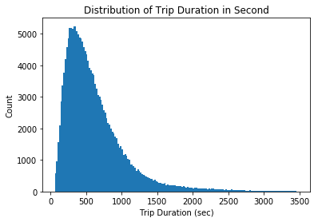

```python
# distribution of trip duration
plt.hist(data = df_bike_copy.query('duration_sec < 3457'), x = 'duration_sec', bins = np.arange(60, 3500, 20))
plt.xlabel('Trip Duration (sec)')
plt.ylabel('Count')
plt.title('Distribution of Trip Duration in Second')
```

**Finding: After cutting the trip duration data at .99 percentile, the distribution of trip duration is positively(right)-skewed, with an average value of 621 seconds (10.35 min) on the 181382 observations. 75% of the riders finished their rides within 784 seconds (13.07 min).**

**(2) The distribution of trip distance**

To find each trip's distance (not given directly in the data set), I need to first define a function that calculate distances based on two locations' latitudes and longitudes, and I found a package call **geopy.distance** that works for our case.

```python
# function to calculate distance (in meter) give 2 latitudes and longitudes
def geo_distance(list):
    loc1 = (list[0], list[1])
    loc2 = (list[2], list[3])

    return geopy.distance.distance(loc1, loc2).m
```

```python
# apply the dustance function and add distance column to each row
attributes = ['start_station_latitude', 'start_station_longitude', 'end_station_latitude', 'end_station_longitude']
df_bike_copy['distance'] = df_bike_copy[attributes].apply(geo_distance, axis = 1)
```

```python
# statistics on trip distance
df_bike_copy['distance'].describe()
```

```
count    183215.000000
mean       1691.247186
std        1097.178647
min           0.000000
25%         909.777251
50%        1431.357962
75%        2227.240841
max       69465.977135
Name: distance, dtype: float64
```

Similar to the trip duration, we also have the issue that the max distance is unrealistically long (**69.465 km**), I decided to cut off at .99 percentile as well.

```python
df_bike_copy['distance'].quantile(.99)
```

```
5063.37242497863
```

There is one more issue, that if the distance is, e.g. 0 m, it might indicate that the rider eventually didn't use the bike for various reasons (such as failed to unlock the bike, etc.), so I would also like to cut off if the distance is below 1 m.

```python
# new statistics after cutting off above 1 meter and below .99 quantile
df_bike_copy.query('(distance > 1) & (distance < 5070)')['distance'].describe()
```

```
count    177564.000000
mean       1682.915003
std         976.655662
min          13.307064
25%         936.749271
50%        1445.277458
75%        2215.371960
max        5067.299998
Name: distance, dtype: float64
```

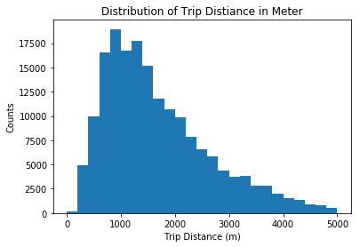

```python
# distribution of trip distance
plt.hist(data = df_bike_copy.query('(distance > 1) & (distance < 5070)'), x = 'distance', bins = np.arange(0, 5070, 200))

plt.xlabel('Trip Distance (m)')
plt.ylabel('Counts')
plt.title('Distribution of Trip Distiance in Meter')
```

**Finding: the distribution of the trip distances is also positively(right)-skewed. The average distance of each trip is ~1.68 km. 75% of the trips are within 2.22 km.**

I would like to do some extra analysis, focusing on the observations where the trip distances are less than 1 m.

```python
# number of observations where distance < 1 m
df_bike_copy.query('distance < 1').shape[0]
```

```
3822
```

```python
# percentage of within-1-meter trip in all the observations
df_bike_copy.query('distance < 1').shape[0]/df_bike_copy.shape[0]
```

```
0.020860737385039435
```

```python
# the distance is < 1 m but the duration is > 10 min
df_bike_copy.query('(distance < 1) & (duration_sec > 600)').shape[0]/df_bike_copy.query('distance < 1').shape[0]
```

```
0.6355311355311355
```

**Finding: There are 3822 rides with recorded distance less than 1 m, which accounts for 2.09% of the total observations. However 63.5% of these trips have durations more than 10 min. This could indicate that the riders brought back the bikes to the station where they started their rides.**

**(3) The distribution of user's age**

```python
# calculate age from birthyear
df_bike_copy['age'] = 2019 - df_bike_copy['member_birth_year']
```

```python
# statistics on age
df_bike_copy['age'].describe()
```

```
count    174952.000000
mean         34.196865
std          10.118731
min          18.000000
25%          27.000000
50%          32.000000
75%          39.000000
max         141.000000
Name: age, dtype: float64
```

We can see that the user needs to be at least 18 to rent a bike. There are ages, such as 141, that is obviously wrong (the user just entered a random number I guess), so I set the plotting upper limit to 60 years old to see the distribution.

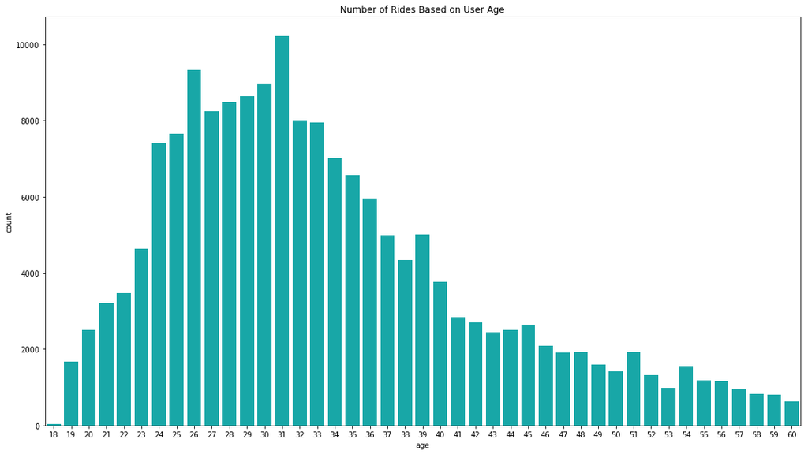

```python
# user age distribution
fig, ax = plt.subplots(figsize = (18,10))
ax = sns.countplot(x = "age", data = df_bike_copy.query('age <= 60'), color = 'c')
ax.set_xticklabels(range(18, 61, 1))
ax.set_title('Number of Rides Based on User Age')
```

**Finding: From the 174952 non-empty entries on birthyear, we extracted the ages of users. To rent a bike, the user needs to be at least 18 years old, 75% of the users are younger than 39 years old. The highest renting count (more than 10000 times) is from 31-year-old age group, The GoBike is much more popular among young people.**

**(4) The distribution of user's gender**

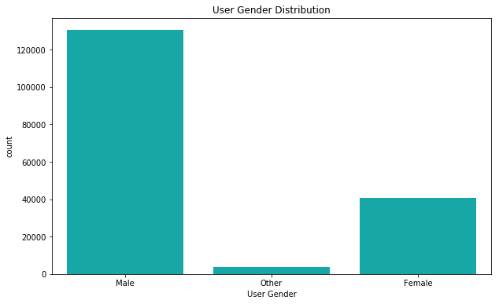

```python
# plot ride counts on genders
fig, ax = plt.subplots(figsize = (10,6))
ax = sns.countplot(x = "member_gender", data = df_bike_copy, color = 'c')
ax.set_title('User Gender Distribution')
ax.set_xlabel('User Gender')
```

**Finding: From all the observations, male users have used the GoBike much more frequently, and they recored ~130000 times of rides. In comparison, female users rided with GoBike for ~40000 times. A couple of thousands rides go to users with other genders.**

**(5) The distribution of user's type**

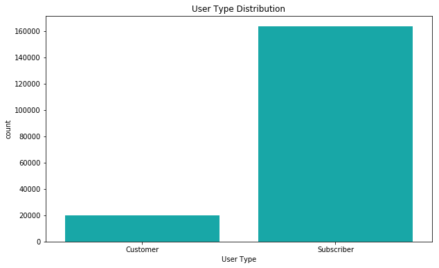

```python
# plot ride counts on user type
fig, ax = plt.subplots(figsize = (10,6))
ax = sns.countplot(x = "user_type", data = df_bike_copy, color = 'c')
ax.set_title('User Type Distribution')
ax.set_xlabel('User Type')
```

```python
# user type ratio
customer_ratio = df_bike_copy.query('user_type == "Customer"').shape[0] / df_bike_copy.shape[0]
subscriber_ratio = df_bike_copy.query('user_type == "Subscriber"').shape[0] / df_bike_copy.shape[0]
print (customer_ratio, subscriber_ratio)
```

```
0.10807521218240865 0.8919247878175913
```

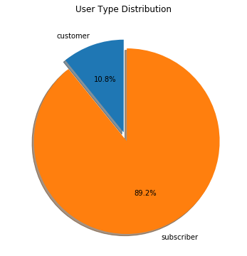

```python
pie_data = [customer_ratio, subscriber_ratio]
fig, ax = plt.subplots(figsize = (10,6))
plt.pie(pie_data, explode=[0, 0.1], labels=['customer', 'subscriber'], startangle=90, autopct='%1.1f%%', shadow=True)
plt.title('User Type Distribution')
```

**(6) Renting counts on day of week**

```python
# extract day of week from starting time column
df_bike_copy['day_of_week'] = df_bike_copy['start_time'].dt.day_name()
```

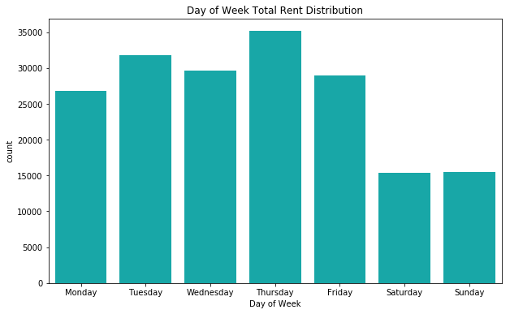

```python
# distribution of rentals from day of week
fig, ax = plt.subplots(figsize = (10,6))
ax = sns.countplot(x = "day_of_week", data = df_bike_copy, color = 'c',
                  order=['Monday','Tuesday','Wednesday','Thursday','Friday','Saturday','Sunday'])
ax.set_title('Day of Week Total Rent Distribution')
ax.set_xlabel('Day of Week')
```

**Finding: There are 28 days in Feb 2019, therefore, each day of the week appears 4 times equally. The number of rides is much higher in weekdays than weekend. The plot shows that total rental number is ~15000 times on both Saturday and Sunday, and more than 25000 times in any of the weekdays. Therefore, it seems that the majoriy of bike rides are for work commutions.**

**(7) Renting counts on hour of day**

```python
# extract hour from start time
df_bike_copy['hour'] = df_bike_copy['start_time'].dt.hour
```

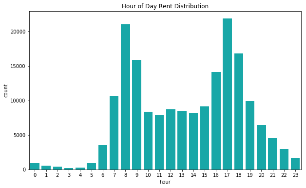

```python
# distribution of rentals from hour of day
fig, ax = plt.subplots(figsize = (10,6))
ax = sns.countplot(x = "hour", data = df_bike_copy, color = 'c')
ax.set_title('Hour of Day Rent Distribution')
```

**Finding: More people used GoBike during the rush hours. The plot showsa bimodel distribution, with modes at 8:00 am and 17:00 pm. Therefore, It is clear that most users take the rental bikes for work commuting.**

### Discuss the distribution(s) of your variable(s) of interest. Were there any unusual points? Did you need to perform any transformations?

To investigate the day of week and hour of day distribution, I changed the data type of start_time, end_time to **datetime**, and used the to_datetime method to get day of week and hour information.

### Of the features you investigated, were there any unusual distributions? Did you perform any operations on the data to tidy, adjust, or change the form of the data? If so, why did you do this?

I assessed the original data set in various ways to find unusual distributions and parts that need cleaning:

## Bivariate Exploration

Based on the univariate exploration, I looked further at some relations between different features and they include:

- Distribution of rentals on day of week by user type
- Distribution of rentals on day of week by user gender
- Average ride distance by day of month
- Average ride duration by day of month
- Ride duration distribution at the 5 most visited stations
- Relation between ride distance and duration

**(1) Distribution of rentals on day of week by user type**

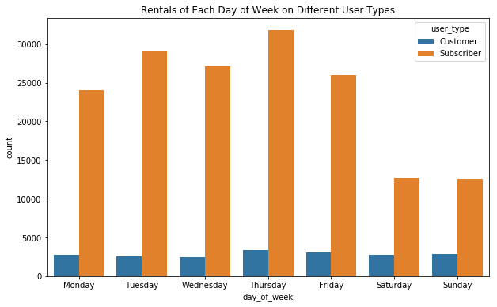

```python
# rentals of each day of week on different user types
fig, ax = plt.subplots(figsize = (10,6))
ax = sns.countplot(x = "day_of_week", hue = 'user_type', data = df_bike_copy,
                  order = ['Monday','Tuesday','Wednesday','Thursday','Friday','Saturday','Sunday'])
ax.set_title('Rentals of Each Day of Week on Different User Types')
```

**(2) Distribution of rentals on day of week by user gender**

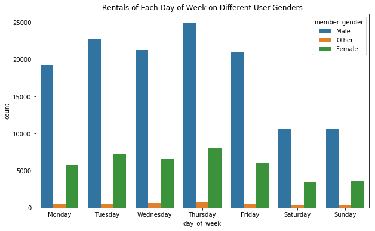

```python
# rentals of each day of week on different user genders
fig, ax = plt.subplots(figsize = (10,6))
ax = sns.countplot(x = "day_of_week", hue = 'member_gender', data = df_bike_copy,
                  order = ['Monday','Tuesday','Wednesday','Thursday','Friday','Saturday','Sunday'])
ax.set_title('Rentals of Each Day of Week on Different User Genders')
```

**Finding: We see similar patterns on day-of-week rentals throughout genders (male/female/other), more uses are recorded on weekdays than weekends (for commuting purpose).**

**(3) Average ride distance by day of month**

```python
# add a day column using start_time
df_bike_copy['day'] = df_bike_copy['start_time'].dt.day
```

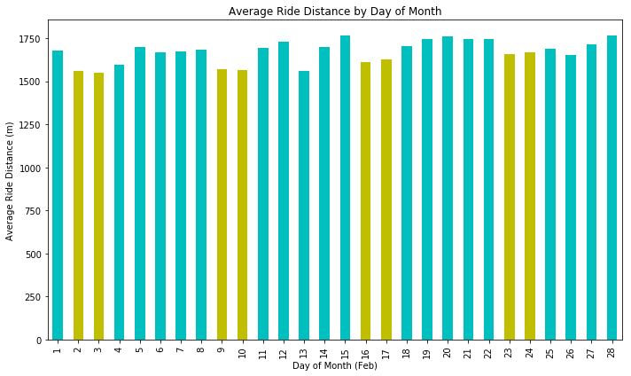

```python
# plotting color: 'y' on weekends, 'c'on weekdays for Feb 2019
colors = ('c','y','y','c','c','c','c','c', 'y','y','c','c','c','c','c',
         'y','y','c','c','c','c','c', 'y','y','c','c','c','c')

# groupby data by day and find the average value
df_avg_distance = df_bike_copy.groupby('day')['distance'].mean()

# visualize using a bar plot
df_avg_distance.plot.bar(figsize = (10, 6), color = colors)
plt.title('Average Ride Distance by Day of Month')
plt.xlabel('Day of Month (Feb)')
plt.ylabel('Average Ride Distance (m)')
plt.tight_layout()
```

**(4) Average ride duration by day of month**

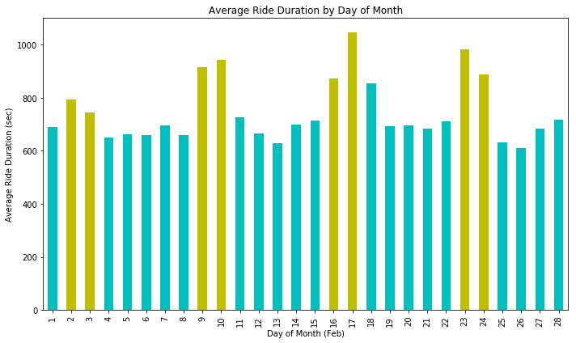

```python
# groupby data by day and find the average value
df_avg_distance = df_bike_copy.groupby('day')['duration_sec'].mean()

# visualize using a bar plot
df_avg_distance.plot.bar(figsize = (10, 6), color = colors)
plt.title('Average Ride Duration by Day of Month')
plt.xlabel('Day of Month (Feb)')
plt.ylabel('Average Ride Duration (sec)')
plt.tight_layout()
```

**(5) Ride duration distribution at the 5 most visited stations**

```python
# first count rentals at each start station and find the top 5
top_station = df_bike_copy['start_station_name'].value_counts().index[:5]

# I cut off the duration at 3457 s (.99 percentile) same as before
df_top5_stations = df_bike_copy.query('duration_sec < 3457').loc[df_bike_copy['start_station_name'].isin(top_station)]
```

```python
# show the top stations
top_station
```

```
Index(['Market St at 10th St',
       'San Francisco Caltrain Station 2  (Townsend St at 4th St)',
       'Berry St at 4th St',
       'Montgomery St BART Station (Market St at 2nd St)',
       'Powell St BART Station (Market St at 4th St)'],
      dtype='object')
```

```
(0, 2000)
```

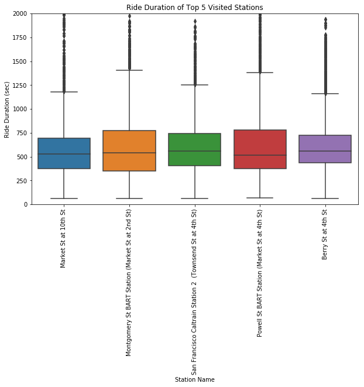

```python
# for top 5 starting stations, I use box plot to find the duration distribution
fig, ax = plt.subplots(figsize = (10,6))
ax = sns.boxplot(x = 'start_station_name', y = 'duration_sec', data = df_top5_stations)

plt.title('Ride Duration of Top 5 Visited Stations')
plt.xlabel('Station Name')
plt.ylabel('Ride Duration (sec)')
plt.xticks(rotation = 90)
plt.ylim(0, 2000)
```

**(6) Relation between ride distance and duration**

```python
# I will use the 10 & 90 percentile of duration sec to tidy the data
print (df_bike_copy['duration_sec'].quantile(.9))
print (df_bike_copy['duration_sec'].quantile(.1))
```

```
1178.0
214.0
```

```python
# query the data between .1 and .9 quantile to remove outliers
df_quantiled_bike_copy = df_bike_copy.query('(duration_sec < 1178.0) & (duration_sec > 214.0)')

# calculate the correlation coefficient between duration and distance
correlation = df_quantiled_bike_copy['duration_sec'].corr(df_quantiled_bike_copy['distance'])
print (correlation)
```

```
0.7459935605464151
```

```python
# use a linear regression on distance vs duration
regression_model = LinearRegression()
x = df_quantiled_bike_copy[['duration_sec']]
y = df_quantiled_bike_copy[['distance']]
# fit the data
regression_model.fit(x, y)
# predict the values with the x data to get the trend line
df_quantiled_bike_copy["trend_line"] = regression_model.predict(x)
```

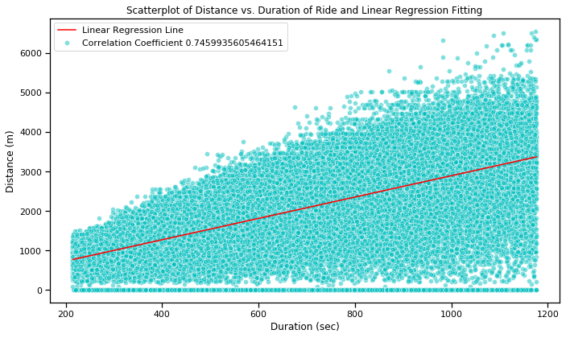

```python
# visualize the data as scatterplot and the trend line
with sns.plotting_context("notebook"):
# create a matplotlib figure
    fig, ax = plt.subplots(figsize = (10,6))
    # plot the scatterplot of distance vs duration
    sns.scatterplot(x = "duration_sec", y = "distance", data = df_quantiled_bike_copy,
                    label="Correlation Coefficient {}".format(correlation), alpha = 0.5, color = "c")
    # plot the trend line
    sns.lineplot(x = "duration_sec", y = "trend_line", data = df_quantiled_bike_copy,
                 label = "Linear Regression Line", color = "r")
    # set the title, legend, x & y labels
    ax.set_title('Scatterplot of Distance vs. Duration of Ride and Linear Regression Fitting')
    ax.legend(loc='best')
    ax.set_xlabel('Duration (sec)')
    ax.set_ylabel('Distance (m)')
    plt.tight_layout()
```

**Finding: For the trimmed GoBike data set (use observations between the .1 and .9 quantile based on diration sec), we can see that the trip distance and duration are positively highly correlated with a coefficient of 0.75. It's as expected, the longer the distance, the more time it takes.**

## Multivariate Exploration

Extended from univariate and bivariate explorations, now we investigate multi-variables, I'm interested in the following:

- Distribution of ride duration based on gender and age
- Number of rides during day of week per age group
- Average trip distance during each hour of day in different regions (I will define regions later in this section)
- Average trip duration during each hour of day in different regions

Note that in the univariate exploration section, when we plotted the latitudes and longitudes of all observations, we obsered 4 clusters (one deleted due to missing values), I will define each cluster more carefully in this section and provide more analysis.

**(1) Distribution of ride duration based on gender and age**

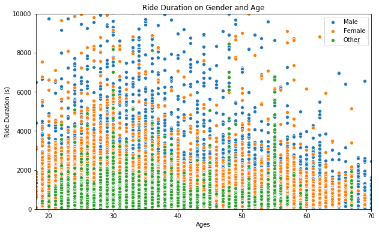

```python
# scatterplot of duration on gender and age
plt.figure(figsize = (10,6))

# query each gender subset and plot separately
for gender in ['Male', 'Female', 'Other']:
    df_gender = df_bike_copy[df_bike_copy['member_gender'] == gender]
    sns.scatterplot(x = "age", y = "duration_sec", data = df_gender)
    plt.legend(['Male', 'Female', 'Other'])
    plt.xlim(18, 70)
    plt.ylim(0, 10000)
    plt.title('Ride Duration on Gender and Age')
    plt.xlabel('Ages')
    plt.ylabel('Ride Duration (s)')
```

**Finding: It seems that ride durations from other genders are less than ride durations from females and males on average throughout different ages. For data points that have ride duration values larger than 4000s (67 min, likely to be outliers), most of them come from male users (blue), which indicates males might be "less careful" than females to return the bikes.**

**(2) Number of rides during day of week per age group**

```python
# first add age group column

age_bins = [0, 19, 29, 39, 49, 59, 69, 79, 89, 99]
age_labels = ['10-19', '20-29', '30-39', '40-49', '50-59', '60-69', '70-79', '80-89', '90-99']

df_bike_copy['age_group'] = pd.cut(df_bike_copy['age'], bins = age_bins, labels = age_labels, right = False)
df_bike_copy[['age','age_group']].head()
```

|  | age | age_group |
| --- | --- | --- |
| 0 | 35.0 | 30-39 |
| 1 | NaN | NaN |
| 2 | 47.0 | 40-49 |
| 3 | 30.0 | 30-39 |
| 4 | 45.0 | 40-49 |

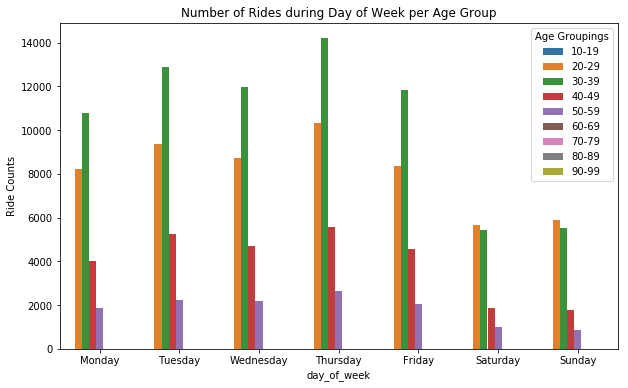

```python
# rides counts on age group and day of week, save in df_age_dow
df_age_dow = df_bike_copy.loc[df_bike_copy['age_group'].isin(['10-19', '20-29', '30-39', '40-49', '50-59'])]

# visualization
plt.figure(figsize = (10, 6))

ax = sns.countplot(data = df_age_dow, x = 'day_of_week', hue = 'age_group',
                  order=['Monday','Tuesday','Wednesday','Thursday','Friday','Saturday','Sunday'])

plt.title('Number of Rides during Day of Week per Age Group')
plt.legend(title = 'Age Groupings', loc = 'upper right')
plt.ylabel('Ride Counts')
```

**Finding: During weekdays, the rentals come from people between 30-39 the most, followed by people between 20-29 who rented 2000-4000 times fewer. Whereas in the weekend, 20-29 group takes over and makes the most rentals, they only lead 30-39 group by a few hundred.**

**(3) Average trip distance distribution during each hour of day in different regions**

First, let's review the locations of the start stations.

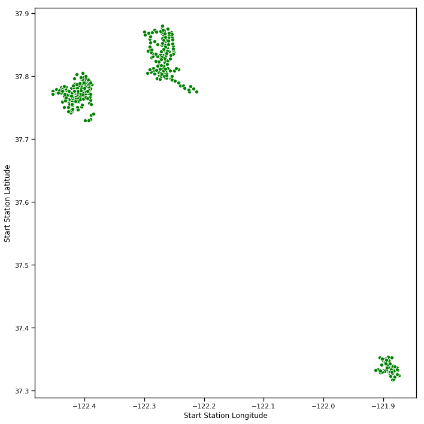

```python
# plot all latitudes and longitudes of start stations
with sns.plotting_context("notebook"):
    # create a matplotlib figure
    fig, ax = plt.subplots(figsize = (10,10))
    sns.scatterplot(y = "start_station_latitude", x = "start_station_longitude", data = df_bike_copy, color = 'g')
    plt.ylabel('Start Station Latitude')
    plt.xlabel('Start Station Longitude')
    plt.tight_layout()
```

I searched in Google map these locations and found they (from left to right) correspond to **San Francisco, Oakland and San Jose**. Now, I will add a column in the df_bike_copy data set that records the region infomation based on start stations.

```python
# function that returns region based on longitudes
def region(x):
    if x < -122.35:
        return 'San Francisco'
    elif x < -122.10:
        return 'Oakland'
    else:
        return 'San Jose'
```

```python
# apply the dustance function and add distance column to each row
df_bike_copy['region'] = df_bike_copy['start_station_longitude'].apply(region)
```

```python
# data head after adding region info
df_bike_copy.head()
```

|  | duration_sec | start_time | end_time | start_station_id | start_station_name | start_station_latitude | start_station_longitude | end_station_id | end_station_name | end_station_latitude | ... | member_birth_year | member_gender | bike_share_for_all_trip | distance | age | day_of_week | hour | day | age_group | region |
| --- | --- | --- | --- | --- | --- | --- | --- | --- | --- | --- | --- | --- | --- | --- | --- | --- | --- | --- | --- | --- | --- |
| 0 | 52185 | 2019-02-28 17:32:10.145 | 2019-03-01 08:01:55.975 | 21.0 | Montgomery St BART Station (Market St at 2nd St) | 37.789625 | -122.400811 | 13.0 | Commercial St at Montgomery St | 37.794231 | ... | 1984.0 | Male | No | 543.983209 | 35.0 | Thursday | 17 | 28 | 30-39 | San Francisco |
| 1 | 42521 | 2019-02-28 18:53:21.789 | 2019-03-01 06:42:03.056 | 23.0 | The Embarcadero at Steuart St | 37.791464 | -122.391034 | 81.0 | Berry St at 4th St | 37.775880 | ... | NaN | NaN | No | 1739.909418 | NaN | Thursday | 18 | 28 | NaN | San Francisco |
| 2 | 61854 | 2019-02-28 12:13:13.218 | 2019-03-01 05:24:08.146 | 86.0 | Market St at Dolores St | 37.769305 | -122.426826 | 3.0 | Powell St BART Station (Market St at 4th St) | 37.786375 | ... | 1972.0 | Male | No | 2705.389951 | 47.0 | Thursday | 12 | 28 | 40-49 | San Francisco |
| 3 | 36490 | 2019-02-28 17:54:26.010 | 2019-03-01 04:02:36.842 | 375.0 | Grove St at Masonic Ave | 37.774836 | -122.446546 | 70.0 | Central Ave at Fell St | 37.773311 | ... | 1989.0 | Other | No | 260.895874 | 30.0 | Thursday | 17 | 28 | 30-39 | San Francisco |
| 4 | 1585 | 2019-02-28 23:54:18.549 | 2019-03-01 00:20:44.074 | 7.0 | Frank H Ogawa Plaza | 37.804562 | -122.271738 | 222.0 | 10th Ave at E 15th St | 37.792714 | ... | 1974.0 | Male | Yes | 2412.017341 | 45.0 | Thursday | 23 | 28 | 40-49 | Oakland |

5 rows × 23 columns

```python
# observation counts in different regions
df_bike_copy['region'].value_counts()
```

```
San Francisco    133708
Oakland           41434
San Jose           8073
Name: region, dtype: int64
```

**We have 133708 rentals from San Francisco area, 41434 rentals from Oakland and 8073 rentals from San Jose.** I will replot the locations of start stations of all the rentals, using different colors to represent different regions.

I would like to overwrite the saved clean file since now we have an extra region column.

```python
# save the cleaned data
df_bike_copy.to_csv("GoBike_Cleaned.csv", index = False)
```

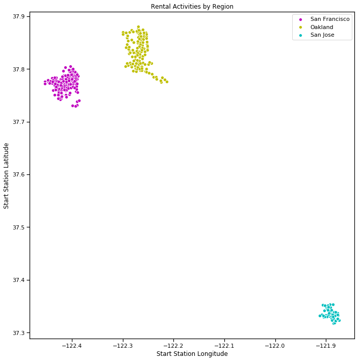

```python
# visualize different regions
with sns.plotting_context("notebook"):
    # create a matplotlib figure
    fig, ax = plt.subplots(figsize = (10,10))
    sns.scatterplot(y = "start_station_latitude", x = "start_station_longitude", data = df_bike_copy.query("region == 'San Francisco'"),
                    label = 'San Francisco', color = 'm',)
    sns.scatterplot(y = "start_station_latitude", x = "start_station_longitude", data = df_bike_copy.query("region == 'Oakland'"),
                    label = 'Oakland', color = 'y')
    sns.scatterplot(y = "start_station_latitude", x = "start_station_longitude", data = df_bike_copy.query("region == 'San Jose'"),
                    label = 'San Jose', color = 'c')
    plt.title('Rental Activities by Region')
    plt.ylabel('Start Station Latitude')
    plt.xlabel('Start Station Longitude')
    plt.legend()
    plt.tight_layout()
```

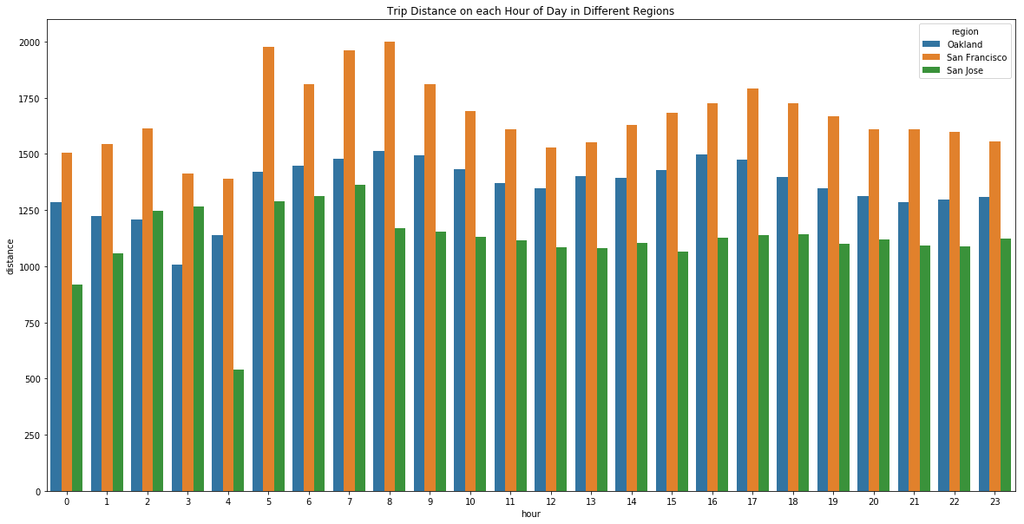

```python
# plot trip distance on each hour of day in different regions
# cut off at .99 percentile, 5070 meter
fig, ax = plt.subplots(figsize = (20,10))
sns.barplot(x = 'hour', y = 'distance', data = df_bike_copy.query('distance < 5070').groupby(['hour', 'region'], as_index = False).mean(), hue = 'region')
plt.title('Trip Distance on each Hour of Day in Different Regions')
```

**Finding: Compared between the regions of San Francisco, Oakland and San Jose, we can see that on average the ride distance over hour in each region follows similar rush-hour pattern as peaks are observed at ~8 am and ~5 pm. San Francisco riders took the longest trip, averaged over 1.5 km, Oakland, San Jose are the second (~1.4 km) and the third (~1.2 km) (we expect this because SF is a larger city with more populations).**

**(4) Average trip duration during each hour of day in different regions**

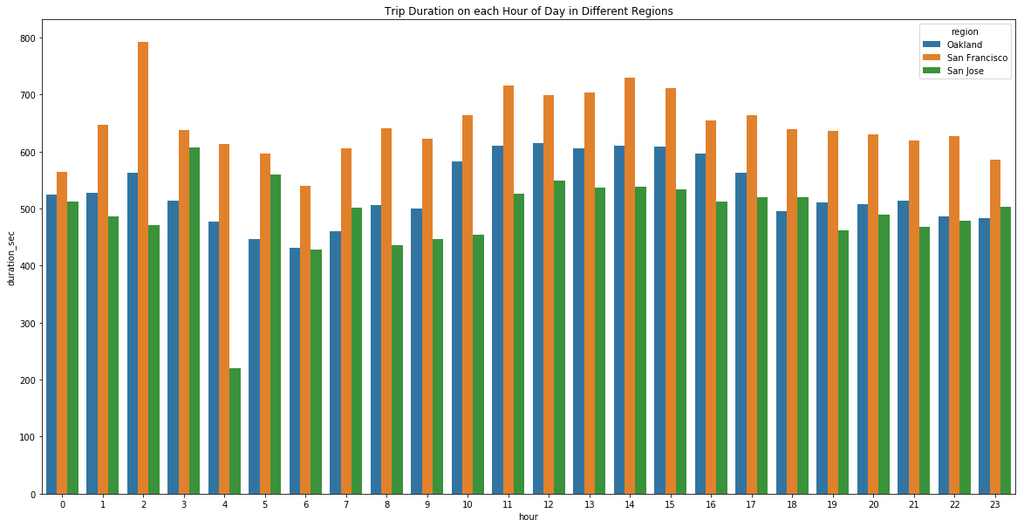

```python
# plot trip duration on each hour of day in different regions
# cut off at .99 percentile, 3457 sec
fig, ax = plt.subplots(figsize = (20,10))
sns.barplot(x = 'hour', y = 'duration_sec', data = df_bike_copy.query('duration_sec < 3457').groupby(['hour', 'region'], as_index = False).mean(), hue = 'region')
plt.title('Trip Duration on each Hour of Day in Different Regions')
```

**Finding: Compared between the regions of San Francisco, Oakland and San Jose, on average the ride duration over hour in each region follows the similar pattern and in contrast to the ride distance, peak is located at noon. San Francisco riders took the longest trip (over 10 min), Oakland, San Jose are the second (~9.2 min) and the third (~8.3 min) (again we expect this because SF is a larger city with more populations).**

### Talk about some of the relationships you observed in this part of the investigation. Were there features that strengthened each other in terms of looking at your feature(s) of interest?

From the multivariate exploration, I have the follow findings:

- Ride durations from other genders are less than ride durations from females and males on average throughout different ages. For data points that have ride duration values larger than 4000s (67 min, likely to be outliers), most of them come from male users (blue), which indicates males might be "less careful" than females to return the bikes.
- During weekdays, the rentals come from people between 30-39 the most, followed by people between 20-29 who rented 2000-4000 times fewer. Whereas in the weekend, 20-29 group takes over and makes the most rentals, they only lead 30-39 group by a few hundred.
- We have 133708 rentals from San Francisco area, 41434 rentals from Oakland and 8073 rentals from San Jose.
- Compared between the regions of San Francisco, Oakland and San Jose, we can see that on average the ride distance over hour in each region follows similar rush-hour pattern as peaks are observed at ~8 am and ~5 pm. San Francisco riders took the longest trip, averaged over 1.5 km, Oakland, San Jose are the second (~1.4 km) and the third (~1.2 km) (we expect this because SF is a larger city with more populations).
- Compared between the regions of San Francisco, Oakland and San Jose, on average the ride duration over hour in each region follows the similar pattern and in contrast to the ride distance, peak is located at noon. San Francisco riders took the longest trip (over 10 min), Oakland, San Jose are the second (~9.2 min) and the third (~8.3 min) (again we expect this because SF is a larger city with more populations).

From the point that 30-39 age group used far more rentals during weekday, it strengthens the point that **the use of GoBike during weekdays is majorly for work commuting**.

### Were there any interesting or surprising interactions between features?

This is the interesting thing I found:

- On average the ride distance over hour in each region follows similar rush-hour pattern as peaks are observed at ~8 am and ~5 pm. however, the ride duration over hour in each region follows a different pattern, in contrast to the ride distance, peak is located at noon. The explanation might be at noon people rent the bike to get lunch nearby, therefore, it takes longer time but shorter distance, whereas during rush hours, people rides for a longer distance (from company to metro station for example), and it takes less time.

## Conclusion

In this project, I explored the **Ford GoBike system data**. We have made **7 univariate explorations, 6 bivariate explorations and 4 multivariate explorations**. At the beginning I gave three questions (actually we explored questions far more than these), I will provide some insights for them here:

- When are most trips taken in terms of time of day or day of the week? (**In terms of time of day, most trips are taken at 8 am and 5 pm, in terms of day of week, most trips are taken on weekdays.**)
- How long does the average trip take? (**On average the trip takes 621 seconds (10.35 min)**)
- Does the above depend on if a user is a subscriber or customer? (**For subscriber it takes on average 589 seconds, whereas it takes 904 seconds for customer.**)